# Decline in cart-to-purchase conversion

December 2025

# **TABLE OF CONTENTS**

- Overview
- Data Preparation
- Exploratory Data Analysis
- Predictive Modeling
- Recommended Solutions

# **OVERVIEW**

## Introduction

1. Understand the data, focusing on customer or product features associated with purchases
2. Determine the impact of a specific problem occurring in a month of data
3. Use models to find patterns that can help marketing or product departments recover lost revenue in future months

## Specific Problem/Challenge

A 10% decline occurs in the cart-to-purchase ratio for a period/month. This implies that there is some issue affecting a user’s likelihood to make a purchase after adding an item to their cart.

## Assumptions

- We use the latest month, February, as the baseline data
- We assume that the decline in purchases is distributed randomly and attempt to understand patterns associated with the decline

## Analysis Process

### Data Preparation Overview

- In order to prepare the data for analysis, we deduplicated and performed some modifications to the data to make it easier to analyze, such as designating user identification as categorical and differentiating product sub-categories, as well as creating multiple versions of the price field in case it was needed in modeling.

### Exploratory Data Analysis Overview

**Exploratory Data Analysis Summary**

- The cart-to-purchase ratio declined by 10% in March compared to February
- Total revenue for February (baseline): $1,376,806
- Financial impact of the decline: $213,921.06 in lost revenue
- Estimated total revenue for March: $1,162,885
- Top categories affected: Videocards
- The top selling products remained the same videocards from February to March
- Most impacted price buckets: $200–$300

### Predictive Modeling Overview

- The goal of our predictive modeling approach was to understand the features and predict the decision likelihood for cart-to-purchase conversion. With a better sense of why some customers were more likely than others to convert to a purchase, we could then identify the key influencers that product and marketing teams can use to influence conversion behavior and increase revenue.
- We used classification tree, random forest, and logistic models to classify the likelihood that a session would convert to a purchase and compared the performance of all three models. We chose these models due to their usefulness in classification analysis, as well as their practicality; implementing these models is fairly straightforward, and if the drop in cart-to-purchase ratio is a continuing issue, we wanted to provide relatively easy-to-implement models for the company to use in addressing this issue on an ongoing basis. Other models, like XGBoost, are more resource-intensive.
- Based on several performance metrics, the random forest model was the most successful at identifying the key factors driving cart-to-purchase conversions. This was the model we selected, allowing us to recommend targeted actions to influence conversion, grounded in statistical insights.
- Then, we simulated a third month in which the higher likelihood sessions are promoted, sufficient to ensure that the total value of purchases increased from $1,162,885 in March to $1,376,806 or more in the next month, recovering lost revenue.
- Additionally, we performed regression analysis to determine the specific revenue impact of increasing an example variable (such as cart additions); however, findings from this model were not chosen for our recommendations given the model’s limited robustness.

## Recommendations Overview

Among customers with the highest likelihood of converting from cart to purchase, the key influencers are:

- **Cart Count:** The number of items added to the cart
- **Session Duration:** The time spent on the platform during a session
- **Views Count:** The number of product views per session
- **Price:** Low- to mid-range items (<$300 USD) are more likely to convert
- **Category Diversity:** Users interacting with multiple categories of products are more likely to convert
- **Product Category:** Specific high-level product categories influence the likelihood of conversion

More detail on specific interventions the company could implement are available in the recommendations section of this report. Additionally, limitations in our analysis are discussed in that section in detail and include assumptions in the distribution of data, incomplete data, model simplifications, and simulation limitations.

In summary, the focus should be on recovering $213,921 in lost revenue through enhanced user engagement, optimized pricing, and category diversity. Immediate actions include cart abandonment campaigns, showcasing bestsellers, and cross-selling prompts, while medium-term strategies involve dynamic pricing, curated promotions, and category exploration.

A campaign that targets these key influencers and that results in a ~20% increase in top likelihood customers and ~20% decrease in lowest likelihood customers would result in a revenue increase of ~$217,000 from March to April, recovering the lost revenue.

# **Step 1: Get required packages, libraries and data**

## Step 1a: Get required packages and libraries

```r
options(repos = c(CRAN = "https://cran.rstudio.com/"))
install.packages("readxl")
install.packages("ROCR")
install.packages("tidyverse")
install.packages("knitr")
install.packages("rmarkdown")
```

```r
install.packages(c("janitor", "rsample", "glmnet", "plotmo",
  "car", "dplyr", "scales", "tidyr", "rpart", "rpart.plot",
  "caret", "randomForest", "ggplot2", "ggpmisc"
))
```

```
##
##  C:\Users\essek\AppData\Local\Temp\RtmpAPBzDm\downloaded_packages
```

```r
options(warn = -1)
suppressMessages(library(readxl))
suppressMessages(library(janitor))
suppressMessages(library(rsample))
suppressMessages(library(ROCR))
suppressMessages(library(glmnet))
suppressMessages(library(plotmo))
suppressMessages(library(car))
suppressMessages(library(dplyr))
suppressMessages(library(scales))
suppressMessages(library(tidyr))
suppressMessages(library(rpart))
suppressMessages(library(rpart.plot))
suppressMessages(library(caret))
suppressMessages(library(randomForest))
suppressMessages(library(rpart))
suppressMessages(library(ROCR))
suppressMessages(library(ggplot2))
suppressMessages(library(ggpmisc))
```

## Steb 1b: Get data

```r
suppressMessages(setwd("C:/Users/essek/OneDrive/Bureau/Desktop PC 3.9.2025/BUAN 650/R Stuff/Final Project 650"))

suppressMessages(FinalProjectData <- read.csv("baseline_data.csv"))
```

# **Step 2: Inspect and clean the data**

## Step 2a: Preliminary step: Create a dataframe

```r
df <- FinalProjectData
```

## Step 2b: View data summaries

```r
head(df)
```

|  | event_time | event_type | product_id | category_id | category_code | brand | price | user_id | user_session | time_month | time_day | time_hour | category_1 | category_2 | category_3 | price_log | price_sqrt |
| --- | --- | --- | --- | --- | --- | --- | --- | --- | --- | --- | --- | --- | --- | --- | --- | --- | --- |
| 1 | 2021-02-01 00:00:24 UTC | view | 3829355 | 2.14442e+18 | electronics.telephone |  | 32.22 | 1.515916e+18 | tLDz4Sqhex | 2 | 1 | 0 | electronics | telephone | NA | 3.472587 | 5.676266 |
| 2 | 2021-02-01 00:00:26 UTC | view | 1079370 | 2.14442e+18 | electronics.telephone |  | 35.71 | 1.515916e+18 | BjS7huYFYy | 2 | 1 | 0 | electronics | telephone | NA | 3.575431 | 5.975784 |
| 3 | 2021-02-01 00:01:21 UTC | view | 4100254 | 2.14442e+18 | computers.components.videocards | asus | 187.29 | 1.515916e+18 | mJndx3tNRh | 2 | 1 | 0 | computers | components | videocards | 5.232658 | 13.685394 |
| 4 | 2021-02-01 00:01:21 UTC | view | 1843522 | 2.14442e+18 |  |  | 15.08 | 1.515916e+18 | JppGOnkO1z | 2 | 1 | 0 | NA | NA | NA | 2.713369 | 3.883298 |
| 5 | 2021-02-01 00:02:01 UTC | view | 4079414 | 2.14442e+18 | electronics.video.tv | starwind | 87.46 | 1.515916e+18 | GprKXGbhaV | 2 | 1 | 0 | electronics | video | tv | 4.471182 | 9.352005 |
| 6 | 2021-02-01 00:02:18 UTC | view | 4156083 | 2.14442e+18 | electronics.clocks |  | 16.19 | 1.515916e+18 | GVeSho4JzN | 2 | 1 | 0 | electronics | clocks | NA | 2.784394 | 4.023680 |

```r
summary(df)
```

```
##   event_time         event_type          product_id       category_id
##  Length:166874      Length:166874      Min.   :    105   Min.   :2.144e+18
##  Class :character   Class :character   1st Qu.: 790605   1st Qu.:2.144e+18
##  Mode  :character   Mode  :character   Median :1633962   Median :2.144e+18
##                                        Mean   :2042929   Mean   :2.144e+18
##                                        3rd Qu.:3791551   3rd Qu.:2.144e+18
##                                        Max.   :4183880   Max.   :2.228e+18
##  category_code         brand               price             user_id
##  Length:166874      Length:166874      Min.   :    0.22   Min.   :1.516e+18
##  Class :character   Class :character   1st Qu.:   31.75   1st Qu.:1.516e+18
##  Mode  :character   Mode  :character   Median :   82.88   Median :1.516e+18
##                                        Mean   :  175.80   Mean   :1.516e+18
##                                        3rd Qu.:  249.17   3rd Qu.:1.516e+18
##                                        Max.   :42590.13   Max.   :1.516e+18
##  user_session         time_month    time_day       time_hour
##  Length:166874      Min.   :2    Min.   : 1.00   Min.   : 0.00
##  Class :character   1st Qu.:2    1st Qu.: 7.00   1st Qu.: 8.00
##  Mode  :character   Median :2    Median :14.00   Median :12.00
##                     Mean   :2    Mean   :14.01   Mean   :12.35
##                     3rd Qu.:2    3rd Qu.:21.00   3rd Qu.:17.00
##                     Max.   :2    Max.   :28.00   Max.   :23.00
##   category_1         category_2         category_3          price_log
##  Length:166874      Length:166874      Length:166874      Min.   :-1.514
##  Class :character   Class :character   Class :character   1st Qu.: 3.458
##  Mode  :character   Mode  :character   Mode  :character   Median : 4.417
##                                                           Mean   : 4.441
##                                                           3rd Qu.: 5.518
##                                                           Max.   :10.659
##    price_sqrt
##  Min.   :  0.469
##  1st Qu.:  5.635
##  Median :  9.104
##  Mean   : 11.211
##  3rd Qu.: 15.785
##  Max.   :206.374
```

## Step 2c: Overall data cleaning and preparation

### Data de-duplication

We needed to de-duplicate data where there are rows with all information the same; these are duplicate data entries, not independent events

```r
# Identify duplicate rows in the data frame
duplicates <- df[duplicated(df) | duplicated(df, fromLast = TRUE), ]

# View the first few rows of duplicates
head(duplicates)
```

| event_time | event_type | product_id | category_id | category_code | brand | price | user_id | user_session | time_month | time_day | time_hour | category_1 | category_2 | category_3 | price_log | price_sqrt |
| --- | --- | --- | --- | --- | --- | --- | --- | --- | --- | --- | --- | --- | --- | --- | --- | --- |

```r
# Get a summary of duplicates
summary(duplicates)
```

```
##   event_time         event_type          product_id   category_id
##  Length:0           Length:0           Min.   : NA   Min.   : NA
##  Class :character   Class :character   1st Qu.: NA   1st Qu.: NA
##  Mode  :character   Mode  :character   Median : NA   Median : NA
##                                        Mean   :NaN   Mean   :NaN
##                                        3rd Qu.: NA   3rd Qu.: NA
##                                        Max.   : NA   Max.   : NA
##  category_code         brand               price        user_id
##  Length:0           Length:0           Min.   : NA   Min.   : NA
##  Class :character   Class :character   1st Qu.: NA   1st Qu.: NA
##  Mode  :character   Mode  :character   Median : NA   Median : NA
##                                        Mean   :NaN   Mean   :NaN
##                                        3rd Qu.: NA   3rd Qu.: NA
##                                        Max.   : NA   Max.   : NA
##  user_session         time_month     time_day     time_hour
##  Length:0           Min.   : NA   Min.   : NA   Min.   : NA
##  Class :character   1st Qu.: NA   1st Qu.: NA   1st Qu.: NA
##  Mode  :character   Median : NA   Median : NA   Median : NA
##                     Mean   :NaN   Mean   :NaN   Mean   :NaN
##                     3rd Qu.: NA   3rd Qu.: NA   3rd Qu.: NA
##                     Max.   : NA   Max.   : NA   Max.   : NA
##   category_1         category_2         category_3          price_log
##  Length:0           Length:0           Length:0           Min.   : NA
##  Class :character   Class :character   Class :character   1st Qu.: NA
##  Mode  :character   Mode  :character   Mode  :character   Median : NA
##                                                           Mean   :NaN
##                                                           3rd Qu.: NA
##                                                           Max.   : NA
##    price_sqrt
##  Min.   : NA
##  1st Qu.: NA
##  Median : NA
##  Mean   :NaN
##  3rd Qu.: NA
##  Max.   : NA
```

```r
count(duplicates)
```

| n |
| --- |
| 0 |

```r
# Remove duplicate rows
deduplicateddf <- distinct(df)
```

### Designate specific columns as character data type

```r
deduplicateddf$product_id <- as.character(deduplicateddf$product_id)
deduplicateddf$category_id <- as.character(deduplicateddf$category_id)
deduplicateddf$user_id <- as.character(deduplicateddf$user_id)
```

### Convert UTC timestamp into separate date and time objects

```r
timestamp_posix <- as.POSIXlt(deduplicateddf$event_time, tz = "UTC")
deduplicateddf$time_month <- timestamp_posix$mon + 1  # Adding 1 because month index starts from 0
deduplicateddf$time_day <- timestamp_posix$mday
deduplicateddf$time_hour <- timestamp_posix$hour
```

### Split the category column

```r
split_categories <- strsplit(deduplicateddf$category_code, "\\.")
deduplicateddf$category_1 <- sapply(split_categories, function(x) x[1])
deduplicateddf$category_2 <- sapply(split_categories, function(x) ifelse(length(x) > 1, x[2], NA))
deduplicateddf$category_3 <- sapply(split_categories, function(x) ifelse(length(x) > 2, x[3], NA))
```

### Create multiple versions of price field if needed in modeling

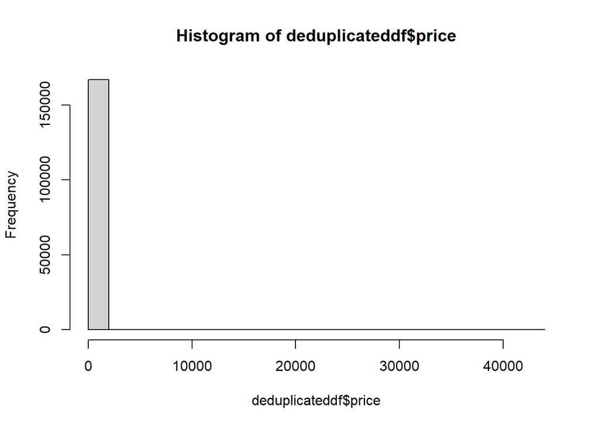

```r
hist(deduplicateddf$price)
```

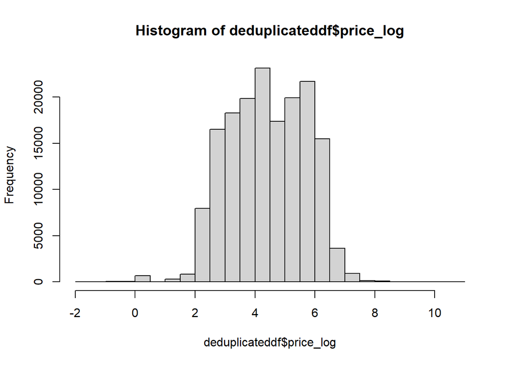

```r
deduplicateddf$price_log = log(deduplicateddf$price)
deduplicateddf$price_sqrt = sqrt(deduplicateddf$price)
hist(deduplicateddf$price_log)
```

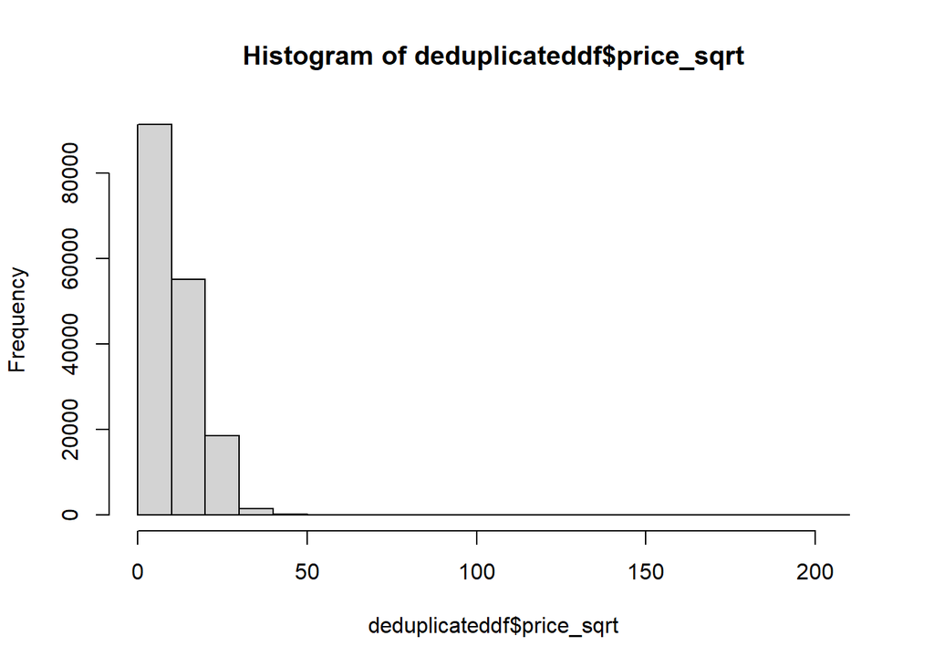

```r
hist(deduplicateddf$price_sqrt)
```

# **Step 3: Exploratory analysis on original, deduplicated data**

## Step 3a: Descriptive Statistics

```r
# Summary statistics
summary_stats <- deduplicateddf %>%
  summarise(
    min_price = min(price, na.rm = TRUE),
    max_price = max(price, na.rm = TRUE),
    mean_price = mean(price, na.rm = TRUE),
    median_price = median(price, na.rm = TRUE),
    total_revenue = sum(price, na.rm = TRUE)
  )

print(summary_stats)
```

```
##   min_price max_price mean_price median_price total_revenue
## 1      0.22  42590.13   175.8044        82.88      29337184
```

```r
# Unique value counts
unique_counts <- deduplicateddf %>%
  summarise(
    unique_products = n_distinct(product_id),
    unique_categories = n_distinct(category_1),
    unique_users = n_distinct(user_id),
    unique_sessions = n_distinct(user_session)
  )

print(unique_counts)
```

```
##   unique_products unique_categories unique_users unique_sessions
## 1           23492                15         4782           89011
```

## Step 3b: Visualizations of Price, Event Types, Revenue

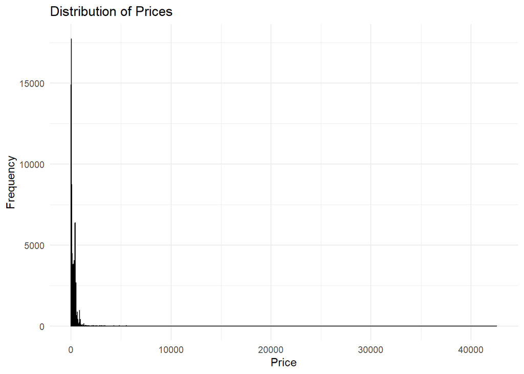

```r
# Distribution of Prices
ggplot(deduplicateddf, aes(x = price)) +
  geom_histogram(binwidth = 10, fill = "blue", color = "black") +
  labs(title = "Distribution of Prices", x = "Price", y = "Frequency") +
  theme_minimal()
```

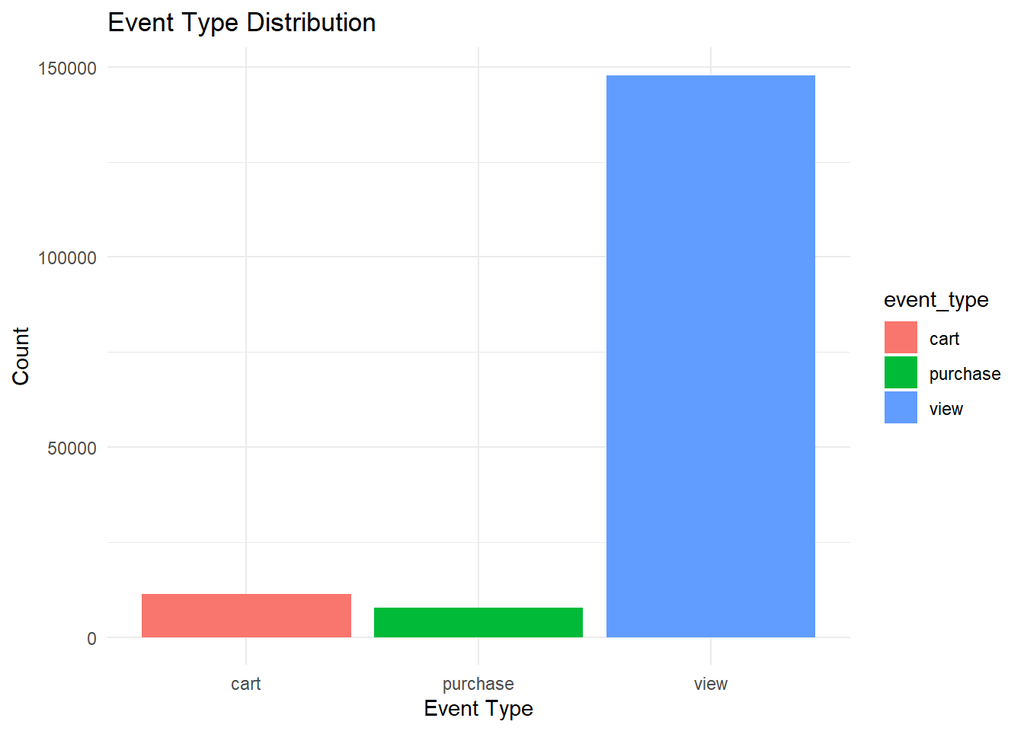

```r
# Distribution of Event Types
event_counts <- deduplicateddf %>%
  group_by(event_type) %>%
  summarise(count = n())

ggplot(event_counts, aes(x = event_type, y = count, fill = event_type)) +
  geom_bar(stat = "identity") +
  labs(title = "Event Type Distribution", x = "Event Type", y = "Count") +
  theme_minimal()
```

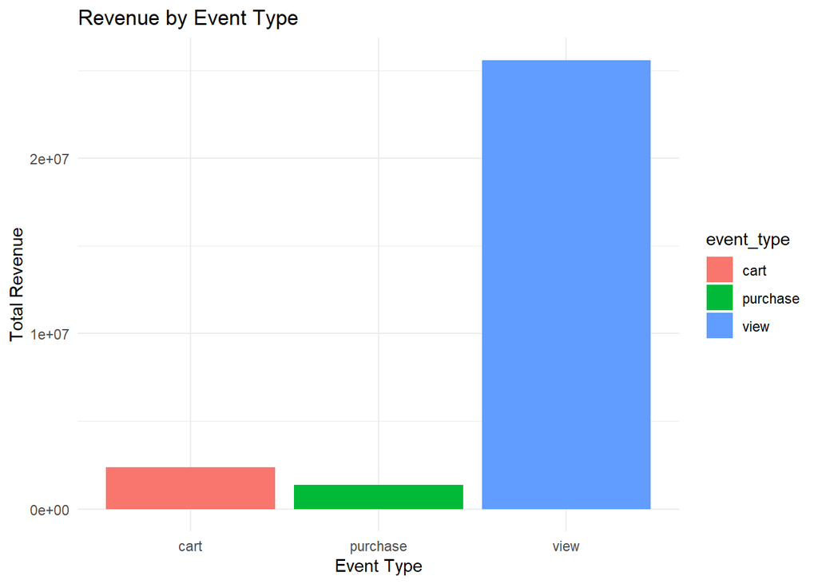

```r
# Total Revenue by Event Type
event_revenue <- deduplicateddf %>%
  group_by(event_type) %>%
  summarise(total_revenue = sum(price, na.rm = TRUE))

ggplot(event_revenue, aes(x = event_type, y = total_revenue, fill = event_type)) +
  geom_bar(stat = "identity") +
  labs(title = "Revenue by Event Type", x = "Event Type", y = "Total Revenue") +
  theme_minimal()
```

## Step 3c: Identify mean and cumulative value by event/action type: View, Cart, Purchase

```r
actionSums <- tapply(deduplicateddf$price, deduplicateddf$event_type, sum)
actionSums_dollar <- dollar(actionSums)
actionSums_dollar
```

```
##          cart      purchase          view
##  "$2,367,791"  "$1,376,806" "$25,592,587"
```

```r
original_cart_to_purchase_ratio <- 5125114/8625870
original_cart_to_purchase_ratio
```

```
## [1] 0.5941562
```

```r
actionMean <- tapply(deduplicateddf$price, deduplicateddf$event_type, mean)
actionMeans_dollar <- dollar(actionMean)
actionMeans_dollar
```

```
##      cart  purchase      view
## "$207.34" "$180.16" "$173.14"
```

## Step 3d: Summarize by user

### Price and price by event types by user

```r
summary_table_userpriceoriginal <- deduplicateddf %>%
  group_by(user_id) %>%
  summarise(
    total_actions = n(),                   # Count of actions per user
    total_price = sum(price, na.rm = TRUE), # Total price per user
    price_view = sum(price[event_type == "view"], na.rm = TRUE), # Sum for event type 1
    price_cart = sum(price[event_type == "cart"], na.rm = TRUE), # Sum for event type 2
    price_purchase = sum(price[event_type == "purchase"], na.rm = TRUE)  # Sum for event type 3
  )

summary_table_userpriceoriginal
```

| user_id | total_actions | total_price | price_view | price_cart | price_purchase |
| --- | --- | --- | --- | --- | --- |
| 1.515915625358e+18 | 5 | 739.45 | 739.45 | 0.00 | 0.00 |
| 1.515915625381e+18 | 4 | 98.72 | 98.72 | 0.00 | 0.00 |
| 1.515915625408e+18 | 7 | 3602.08 | 3602.08 | 0.00 | 0.00 |
| 1.515915625413e+18 | 1 | 14.22 | 14.22 | 0.00 | 0.00 |
| 1.515915625427e+18 | 27 | 3186.00 | 3186.00 | 0.00 | 0.00 |
| 1.515915625456e+18 | 2 | 54.71 | 54.71 | 0.00 | 0.00 |
| 1.515915625517e+18 | 2 | 16.09 | 16.09 | 0.00 | 0.00 |
| 1.515915625521e+18 | 6 | 397.11 | 397.11 | 0.00 | 0.00 |
| 1.515915625525e+18 | 1 | 74.57 | 74.57 | 0.00 | 0.00 |
| 1.515915625528e+18 | 1 | 101.27 | 101.27 | 0.00 | 0.00 |

[output cut: 4772 more lines]

### Cart-to-purchase ratio by user

```r
# Calculate cart-to-purchase ratios by user
cart_purchase_ratio_user <- deduplicateddf %>%
  filter(event_type %in% c("cart", "purchase")) %>%
  group_by(user_id, event_type) %>%
  summarise(
    event_count = n(),
    total_price = sum(price, na.rm = TRUE)
  ) %>%
  pivot_wider(names_from = event_type, values_from = c(event_count, total_price), values_fill = 0) %>%
  mutate(
    cart_to_purchase_ratio_count = ifelse(event_count_cart > 0, event_count_purchase / event_count_cart, NA),
    cart_to_purchase_ratio_price = ifelse(total_price_cart > 0, total_price_purchase / total_price_cart, NA)
  )
# View the results
cart_purchase_ratio_user
```

| user_id | event_count_cart | event_count_purchase | total_price_cart | total_price_purchase | cart_to_purchase_ratio_count | cart_to_purchase_ratio_price |
| --- | --- | --- | --- | --- | --- | --- |
| 1.515915625531e+18 | 2 | 2 | 408.58 | 408.58 | 1.00000000 | 1.000000000 |
| 1.515915625532e+18 | 2 | 2 | 170.82 | 170.82 | 1.00000000 | 1.000000000 |
| 1.51591562557e+18 | 3 | 3 | 483.12 | 481.56 | 1.00000000 | 0.996770989 |
| 1.515915625594e+18 | 1 | 0 | 294.41 | 0.00 | 0.00000000 | 0.000000000 |
| 1.515915625595e+18 | 6 | 7 | 418.23 | 479.40 | 1.16666667 | 1.146259235 |
| 1.515915625599e+18 | 3 | 1 | 247.71 | 17.71 | 0.33333333 | 0.071494893 |
| 1.515915625601e+18 | 24 | 11 | 5648.00 | 461.32 | 0.45833333 | 0.081678470 |
| 1.515915625603e+18 | 10 | 9 | 1179.32 | 307.46 | 0.90000000 | 0.260709561 |
| 1.515915625604e+18 | 15 | 9 | 4765.84 | 2538.33 | 0.60000000 | 0.532609152 |
| 1.515915625605e+18 | 4 | 1 | 641.98 | 397.48 | 0.25000000 | 0.619147014 |

[output cut: 1947 more lines]

## Step 3e: Summarize by session

### Price and price by event types by session

```r
summary_table_sessionpriceoriginal <- deduplicateddf %>%
  group_by(user_session) %>%
  summarise(
    total_actions = n(),                   # Count of actions per user
    total_price = sum(price, na.rm = TRUE), # Total price per user
    price_view = sum(price[event_type == "view"], na.rm = TRUE), # Sum for event type 1
    price_cart = sum(price[event_type == "cart"], na.rm = TRUE), # Sum for event type 2
    price_purchase = sum(price[event_type == "purchase"], na.rm = TRUE)  # Sum for event type 3
  )

summary_table_sessionpriceoriginal
```

| user_session | total_actions | total_price | price_view | price_cart | price_purchase |
| --- | --- | --- | --- | --- | --- |
|  | 7 | 178.57 | 112.54 | 66.03 | 0.00 |
| 009zFA5YxX | 8 | 7373.71 | 6550.98 | 822.73 | 0.00 |
| 00AnjtXSYC | 2 | 24.92 | 12.46 | 12.46 | 0.00 |
| 00BmN7cGsf | 1 | 52.38 | 52.38 | 0.00 | 0.00 |
| 00EDRogZ0C | 1 | 327.43 | 327.43 | 0.00 | 0.00 |
| 00IohNoWif | 5 | 67.72 | 28.24 | 13.16 | 26.32 |
| 00JIsEAwZd | 1 | 43.11 | 43.11 | 0.00 | 0.00 |
| 00TftCvyIS | 1 | 599.38 | 599.38 | 0.00 | 0.00 |
| 00TmG4fWVk | 1 | 258.03 | 258.03 | 0.00 | 0.00 |
| 00V59bFNoX | 1 | 587.60 | 587.60 | 0.00 | 0.00 |

[output cut: 9990 more lines]

### Cart-to-purchase ratio by session

```r
# Calculate cart-to-purchase ratios by session
cart_purchase_ratio_session <- deduplicateddf %>%
  filter(event_type %in% c("cart", "purchase")) %>%
  group_by(user_session, event_type) %>%
  summarise(
    event_count = n(),
    total_price = sum(price, na.rm = TRUE)
  ) %>%
  pivot_wider(names_from = event_type, values_from = c(event_count, total_price), values_fill = 0) %>%
  mutate(
    cart_to_purchase_ratio_count = ifelse(event_count_cart > 0, event_count_purchase / event_count_cart, NA),
    cart_to_purchase_ratio_price = ifelse(total_price_cart > 0, total_price_purchase / total_price_cart, NA)
  )
# View the results
cart_purchase_ratio_session
```

| user_session | event_count_cart | event_count_purchase | total_price_cart | total_price_purchase | cart_to_purchase_ratio_count | cart_to_purchase_ratio_price |
| --- | --- | --- | --- | --- | --- | --- |
|  | 2 | 0 | 66.03 | 0.00 | 0.00000000 | 0.00000000 |
| 009zFA5YxX | 1 | 0 | 822.73 | 0.00 | 0.00000000 | 0.00000000 |
| 00AnjtXSYC | 1 | 0 | 12.46 | 0.00 | 0.00000000 | 0.00000000 |
| 00IohNoWif | 1 | 2 | 13.16 | 26.32 | 2.00000000 | 2.00000000 |
| 00p2pT8yws | 1 | 1 | 203.02 | 203.02 | 1.00000000 | 1.00000000 |
| 01EmbM8CtE | 2 | 3 | 32.22 | 48.33 | 1.50000000 | 1.50000000 |
| 01ITXLVZo5 | 1 | 2 | 13.86 | 27.72 | 2.00000000 | 2.00000000 |
| 01Ohew6vhK | 1 | 2 | 77.40 | 154.80 | 2.00000000 | 2.00000000 |
| 01URkxPdEI | 1 | 1 | 268.79 | 268.79 | 1.00000000 | 1.00000000 |
| 01Ute17GGU | 2 | 1 | 188.12 | 94.06 | 0.50000000 | 0.50000000 |

[output cut: 9336 more lines]

# **Step 4: Isolate baseline month data and create month in which change occurs**

## Step 4a: Extract baseline (February) data and create March (change) data

### Extract baseline month data

Here, we are using the latest month of data, February

```r
# Filter for baseline month (February) and store in a new variable
month_baseline <- deduplicateddf %>%
  filter(time_month == 2)

# View the filtered dataset
head(month_baseline)
```

|  | event_time | event_type | product_id | category_id | category_code | brand | price | user_id | user_session | time_month | time_day | time_hour | category_1 | category_2 | category_3 | price_log | price_sqrt |
| --- | --- | --- | --- | --- | --- | --- | --- | --- | --- | --- | --- | --- | --- | --- | --- | --- | --- |
| 1 | 2021-02-01 00:00:24 UTC | view | 3829355 | 2.14442e+18 | electronics.telephone |  | 32.22 | 1515915625599239936 | tLDz4Sqhex | 2 | 1 | 0 | electronics | telephone | NA | 3.472587 | 5.676266 |
| 2 | 2021-02-01 00:00:26 UTC | view | 1079370 | 2.14442e+18 | electronics.telephone |  | 35.71 | 1515915625599239936 | BjS7huYFYy | 2 | 1 | 0 | electronics | telephone | NA | 3.575431 | 5.975784 |
| 3 | 2021-02-01 00:01:21 UTC | view | 4100254 | 2.14442e+18 | computers.components.videocards | asus | 187.29 | 1515915625599170048 | mJndx3tNRh | 2 | 1 | 0 | computers | components | videocards | 5.232658 | 13.685394 |
| 4 | 2021-02-01 00:01:21 UTC | view | 1843522 | 2.14442e+18 |  |  | 15.08 | 1515915625599239936 | JppGOnkO1z | 2 | 1 | 0 | NA | NA | NA | 2.713369 | 3.883298 |
| 5 | 2021-02-01 00:02:01 UTC | view | 4079414 | 2.14442e+18 | electronics.video.tv | starwind | 87.46 | 1515915625599239936 | GprKXGbhaV | 2 | 1 | 0 | electronics | video | tv | 4.471182 | 9.352005 |
| 6 | 2021-02-01 00:02:18 UTC | view | 4156083 | 2.14442e+18 | electronics.clocks |  | 16.19 | 1515915625597860096 | GVeSho4JzN | 2 | 1 | 0 | electronics | clocks | NA | 2.784394 | 4.023680 |

```r
summary(month_baseline)
```

```
##   event_time         event_type         product_id        category_id
##  Length:166874      Length:166874      Length:166874      Length:166874
##  Class :character   Class :character   Class :character   Class :character
##  Mode  :character   Mode  :character   Mode  :character   Mode  :character
##
##
##
##  category_code         brand               price            user_id
##  Length:166874      Length:166874      Min.   :    0.22   Length:166874
##  Class :character   Class :character   1st Qu.:   31.75   Class :character
##  Mode  :character   Mode  :character   Median :   82.88   Mode  :character
##                                        Mean   :  175.80
##                                        3rd Qu.:  249.17
##                                        Max.   :42590.13
##  user_session         time_month    time_day       time_hour
##  Length:166874      Min.   :2    Min.   : 1.00   Min.   : 0.00
##  Class :character   1st Qu.:2    1st Qu.: 7.00   1st Qu.: 8.00
##  Mode  :character   Median :2    Median :14.00   Median :12.00
##                     Mean   :2    Mean   :14.01   Mean   :12.35
##                     3rd Qu.:2    3rd Qu.:21.00   3rd Qu.:17.00
##                     Max.   :2    Max.   :28.00   Max.   :23.00
##   category_1         category_2         category_3          price_log
##  Length:166874      Length:166874      Length:166874      Min.   :-1.514
##  Class :character   Class :character   Class :character   1st Qu.: 3.458
##  Mode  :character   Mode  :character   Mode  :character   Median : 4.417
##                                                           Mean   : 4.441
##                                                           3rd Qu.: 5.518
##                                                           Max.   :10.659
##    price_sqrt
##  Min.   :  0.469
##  1st Qu.:  5.635
##  Median :  9.104
##  Mean   : 11.211
##  3rd Qu.: 15.785
##  Max.   :206.374
```

### Create March data

```r
month_3 <- month_baseline
month_3$time_month <- 3

head(month_3)
```

|  | event_time | event_type | product_id | category_id | category_code | brand | price | user_id | user_session | time_month | time_day | time_hour | category_1 | category_2 | category_3 | price_log | price_sqrt |
| --- | --- | --- | --- | --- | --- | --- | --- | --- | --- | --- | --- | --- | --- | --- | --- | --- | --- |
| 1 | 2021-02-01 00:00:24 UTC | view | 3829355 | 2.14442e+18 | electronics.telephone |  | 32.22 | 1515915625599239936 | tLDz4Sqhex | 3 | 1 | 0 | electronics | telephone | NA | 3.472587 | 5.676266 |
| 2 | 2021-02-01 00:00:26 UTC | view | 1079370 | 2.14442e+18 | electronics.telephone |  | 35.71 | 1515915625599239936 | BjS7huYFYy | 3 | 1 | 0 | electronics | telephone | NA | 3.575431 | 5.975784 |
| 3 | 2021-02-01 00:01:21 UTC | view | 4100254 | 2.14442e+18 | computers.components.videocards | asus | 187.29 | 1515915625599170048 | mJndx3tNRh | 3 | 1 | 0 | computers | components | videocards | 5.232658 | 13.685394 |
| 4 | 2021-02-01 00:01:21 UTC | view | 1843522 | 2.14442e+18 |  |  | 15.08 | 1515915625599239936 | JppGOnkO1z | 3 | 1 | 0 | NA | NA | NA | 2.713369 | 3.883298 |
| 5 | 2021-02-01 00:02:01 UTC | view | 4079414 | 2.14442e+18 | electronics.video.tv | starwind | 87.46 | 1515915625599239936 | GprKXGbhaV | 3 | 1 | 0 | electronics | video | tv | 4.471182 | 9.352005 |
| 6 | 2021-02-01 00:02:18 UTC | view | 4156083 | 2.14442e+18 | electronics.clocks |  | 16.19 | 1515915625597860096 | GVeSho4JzN | 3 | 1 | 0 | electronics | clocks | NA | 2.784394 | 4.023680 |

## Step 4b: Determine March purchase to cart ratio and alter March data to fit specific problem/challenge

### Determine March purchase to cart ratio

```r
initial_cart_count <- nrow(filter(month_3, event_type == "cart"))
initial_purchase_count <- nrow(filter(month_3, event_type == "purchase"))
initial_ratio <- initial_purchase_count / initial_cart_count
initial_ratio
```

```
## [1] 0.6691769
```

### Apply a reduction to purchase events in March

```r
# Calculate reduction of the purchase events
num_to_remove <- round(initial_purchase_count * 0.15)

# Randomly sample and remove above percentage of purchase events
set.seed(123)  # For reproducibility
purchases_to_remove <- sample(which(month_3$event_type == "purchase"), num_to_remove)
month_3_modified <- month_3[-purchases_to_remove, ]
```

### Calculate final cart-to-purchase ratio for March

```r
final_cart_count <- nrow(filter(month_3_modified, event_type == "cart"))
final_purchase_count <- nrow(filter(month_3_modified, event_type == "purchase"))
final_ratio <- final_purchase_count / final_cart_count
final_ratio
```

```
## [1] 0.5688266
```

```r
cat("Final Cart-to-Purchase Ratio for March after 10% reduction from February:", final_ratio, "\n")
```

```
## Final Cart-to-Purchase Ratio for March after 10% reduction from February: 0.5688266
```

```r
initial_ratio-final_ratio
```

```
## [1] 0.1003503
```

## Step 4c: Combine baseline and modified March data

```r
data_combined <- bind_rows(month_baseline, month_3_modified)

head(data_combined)
```

|  | event_time | event_type | product_id | category_id | category_code | brand | price | user_id | user_session | time_month | time_day | time_hour | category_1 | category_2 | category_3 | price_log | price_sqrt |
| --- | --- | --- | --- | --- | --- | --- | --- | --- | --- | --- | --- | --- | --- | --- | --- | --- | --- |
| 1 | 2021-02-01 00:00:24 UTC | view | 3829355 | 2.14442e+18 | electronics.telephone |  | 32.22 | 1515915625599239936 | tLDz4Sqhex | 2 | 1 | 0 | electronics | telephone | NA | 3.472587 | 5.676266 |
| 2 | 2021-02-01 00:00:26 UTC | view | 1079370 | 2.14442e+18 | electronics.telephone |  | 35.71 | 1515915625599239936 | BjS7huYFYy | 2 | 1 | 0 | electronics | telephone | NA | 3.575431 | 5.975784 |
| 3 | 2021-02-01 00:01:21 UTC | view | 4100254 | 2.14442e+18 | computers.components.videocards | asus | 187.29 | 1515915625599170048 | mJndx3tNRh | 2 | 1 | 0 | computers | components | videocards | 5.232658 | 13.685394 |
| 4 | 2021-02-01 00:01:21 UTC | view | 1843522 | 2.14442e+18 |  |  | 15.08 | 1515915625599239936 | JppGOnkO1z | 2 | 1 | 0 | NA | NA | NA | 2.713369 | 3.883298 |
| 5 | 2021-02-01 00:02:01 UTC | view | 4079414 | 2.14442e+18 | electronics.video.tv | starwind | 87.46 | 1515915625599239936 | GprKXGbhaV | 2 | 1 | 0 | electronics | video | tv | 4.471182 | 9.352005 |
| 6 | 2021-02-01 00:02:18 UTC | view | 4156083 | 2.14442e+18 | electronics.clocks |  | 16.19 | 1515915625597860096 | GVeSho4JzN | 2 | 1 | 0 | electronics | clocks | NA | 2.784394 | 4.023680 |

```r
summary(data_combined)
```

```
##   event_time         event_type         product_id        category_id
##  Length:332602      Length:332602      Length:332602      Length:332602
##  Class :character   Class :character   Class :character   Class :character
##  Mode  :character   Mode  :character   Mode  :character   Mode  :character
##
##
##
##  category_code         brand               price            user_id
##  Length:332602      Length:332602      Min.   :    0.22   Length:332602
##  Class :character   Class :character   1st Qu.:   31.75   Class :character
##  Mode  :character   Mode  :character   Median :   82.86   Mode  :character
##                                        Mean   :  175.77
##                                        3rd Qu.:  249.03
##                                        Max.   :42590.13
##  user_session         time_month       time_day       time_hour
##  Length:332602      Min.   :2.000   Min.   : 1.00   Min.   : 0.00
##  Class :character   1st Qu.:2.000   1st Qu.: 7.00   1st Qu.: 8.00
##  Mode  :character   Median :2.000   Median :14.00   Median :12.00
##                     Mean   :2.498   Mean   :14.01   Mean   :12.35
##                     3rd Qu.:3.000   3rd Qu.:21.00   3rd Qu.:17.00
##                     Max.   :3.000   Max.   :28.00   Max.   :23.00
##   category_1         category_2         category_3          price_log
##  Length:332602      Length:332602      Length:332602      Min.   :-1.514
##  Class :character   Class :character   Class :character   1st Qu.: 3.458
##  Mode  :character   Mode  :character   Mode  :character   Median : 4.417
##                                                           Mean   : 4.441
##                                                           3rd Qu.: 5.518
##                                                           Max.   :10.659
##    price_sqrt
##  Min.   :  0.469
##  1st Qu.:  5.635
##  Median :  9.103
##  Mean   : 11.209
##  3rd Qu.: 15.781
##  Max.   :206.374
```

# **EXPLORATORY DATA ANALYSIS**

# Step 5: Exploratory analysis on change month and differential from baseline month

## Step 5a: Report lost revenue from February to March

- The total loss in revenue is $213,921.06
- The mean purchase value declined from $180.16 to $179.02

### Identify cumulative and mean revenue difference by event type

```r
#Baseline month
actionSumsBaseline <- tapply(month_baseline$price, month_baseline$event_type, sum)
actionSums_dollarBaseline <- dollar(actionSumsBaseline)
actionSums_dollarBaseline
```

```
##          cart      purchase          view
##  "$2,367,791"  "$1,376,806" "$25,592,587"
```

```r
actionMeanBaseline <- tapply(month_baseline$price, month_baseline$event_type, mean)
actionMeans_dollarBaseline <- dollar(actionMeanBaseline)
actionMeans_dollarBaseline
```

```
##      cart  purchase      view
## "$207.34" "$180.16" "$173.14"
```

```r
#Month 3/March
actionSumsMarch <- tapply(month_3_modified$price, month_3_modified$event_type, sum)
actionSums_dollarMarch <- dollar(actionSumsMarch)
actionSums_dollarMarch
```

```
##          cart      purchase          view
##  "$2,367,791"  "$1,162,885" "$25,592,587"
```

```r
actionMeanMarch <- tapply(month_3_modified$price, month_3_modified$event_type, mean)
actionMeans_dollarMarch <- dollar(actionMeanMarch)
actionMeans_dollarMarch
```

```
##      cart  purchase      view
## "$207.34" "$179.02" "$173.14"
```

### Determine total loss in price/value from baseline to March

```r
#Total value loss
actionSums_dollarBaselinePurchase <- month_baseline %>%
  filter(event_type == "purchase") %>%
  summarise(total_revenue = sum(price))

print(actionSums_dollarBaselinePurchase)
```

```
##   total_revenue
## 1       1376806
```

```r
actionSums_dollarMarchPurchase <- month_3_modified %>%
  filter(event_type == "purchase") %>%
  summarise(total_revenue = sum(price))

print(actionSums_dollarMarchPurchase)
```

```
##   total_revenue
## 1       1162885
```

```r
lost_revenue <- actionSums_dollarBaselinePurchase-actionSums_dollarMarchPurchase
message <- paste("The estimated lost monthly revenue is", lost_revenue)
message
```

```
## [1] "The estimated lost monthly revenue is 213921.06"
```

# Step 5b: Factor Analysis

In this section, we will examine how revenue was impacted in terms of several factors: products, pricing, and user engagement features.

### Products

What were the specific products most impacted by the change in terms of lost revenue?

```r
# Filter only purchases
baseline_purchases <- month_baseline %>% filter(event_type == "purchase")
month3_purchases <- month_3_modified %>% filter(event_type == "purchase")

# Summarize revenue by brand and product categories
baseline_revenue <- baseline_purchases %>%
  group_by(brand, category_1, category_2, category_3) %>%
  summarise(total_revenue_baseline = sum(price, na.rm = TRUE), .groups = "drop")

month3_revenue <- month3_purchases %>%
  group_by(brand, category_1, category_2, category_3) %>%
  summarise(total_revenue_month3 = sum(price, na.rm = TRUE), .groups = "drop")

# Merge datasets by brand and product categories
revenue_comparison <- merge(
  baseline_revenue,
  month3_revenue,
  by = c("brand", "category_1", "category_2", "category_3"),
  all = TRUE
)

# Replace NA with 0 (if a brand-category combination is missing in a month)
revenue_comparison[is.na(revenue_comparison)] <- 0

# Calculate revenue decline
revenue_comparison <- revenue_comparison %>%
  mutate(revenue_decline = total_revenue_baseline - total_revenue_month3)

# Sort by largest declines
largest_declines <- revenue_comparison %>%
  arrange(desc(revenue_decline))

# View the table with the biggest declines
print(head(largest_declines, 50))
```

```
##         brand   category_1  category_2   category_3 total_revenue_baseline
## 1         msi    computers  components   videocards              259334.09
## 2       palit    computers  components   videocards              187960.55
## 3    gigabyte    computers  components   videocards              179298.88
## 4        asus    computers  components   videocards              113616.55
## 5    sapphire    computers  components   videocards               99811.30
## 6                computers  components   videocards               77311.06
## 7  powercolor    computers  components   videocards               36226.80
## 8         amd    computers  components          cpu               35858.74
## 9       canon    computers peripherals      printer               15289.56
## 10                       0           0            0               21504.73
## 11  microsoft            0           0            0                8480.72
## 12       sony            0           0            0                7608.82
## 13       asus    computers  components  motherboard                6117.28
## 14             electronics   telephone            0               11212.50
```

[output cut: 87 more lines]

```r
# Best sellers for March
best_sellers_march <- revenue_comparison %>%
  arrange(desc(total_revenue_month3))  # Sort by revenue for March

# View the top 50 best sellers in March
print(head(best_sellers_march, 10))
```

```
##         brand category_1  category_2 category_3 total_revenue_baseline
## 1         msi  computers  components videocards              259334.09
## 2       palit  computers  components videocards              187960.55
## 3    gigabyte  computers  components videocards              179298.88
## 4        asus  computers  components videocards              113616.55
## 5    sapphire  computers  components videocards               99811.30
## 6              computers  components videocards               77311.06
## 7  powercolor  computers  components videocards               36226.80
## 8         amd  computers  components        cpu               35858.74
## 9                      0           0          0               21504.73
## 10      canon  computers peripherals    printer               15289.56
##    total_revenue_month3 revenue_decline
## 1             213058.81        46275.28
## 2             159459.18        28501.37
## 3             152861.08        26437.80
## 4              96380.73        17235.82
## 5              82623.73        17187.57
## 6              67192.70        10118.36
## 7              30944.97         5281.83
## 8              30763.60         5095.14
## 9              18539.71         2965.02
## 10             12221.35         3068.21
```

How were product brands and categories impacted overall by the change in terms of lost revenue?

```r
# Summarize revenue declines by brand
brand_declines <- revenue_comparison %>%
  group_by(brand) %>%
  summarise(
    total_revenue_baseline = sum(total_revenue_baseline, na.rm = TRUE),
    total_revenue_month3 = sum(total_revenue_month3, na.rm = TRUE)
  ) %>%
  mutate(revenue_decline = total_revenue_baseline - total_revenue_month3) %>%
  arrange(desc(revenue_decline))

# Summarize revenue declines by category_1
category_1_declines <- revenue_comparison %>%
  group_by(category_1) %>%
  summarise(
    total_revenue_baseline = sum(total_revenue_baseline, na.rm = TRUE),
    total_revenue_month3 = sum(total_revenue_month3, na.rm = TRUE)
  ) %>%
  mutate(revenue_decline = total_revenue_baseline - total_revenue_month3) %>%
  arrange(desc(revenue_decline))

# Summarize revenue declines by category_2
category_2_declines <- revenue_comparison %>%
  group_by(category_2) %>%
  summarise(
    total_revenue_baseline = sum(total_revenue_baseline, na.rm = TRUE),
    total_revenue_month3 = sum(total_revenue_month3, na.rm = TRUE)
  ) %>%
  mutate(revenue_decline = total_revenue_baseline - total_revenue_month3) %>%
  arrange(desc(revenue_decline))

# Summarize revenue declines by category_3
category_3_declines <- revenue_comparison %>%
  group_by(category_3) %>%
  summarise(
    total_revenue_baseline = sum(total_revenue_baseline, na.rm = TRUE),
    total_revenue_month3 = sum(total_revenue_month3, na.rm = TRUE)
  ) %>%
  mutate(revenue_decline = total_revenue_baseline - total_revenue_month3) %>%
  arrange(desc(revenue_decline))

# View top declines for each summary
print("Top Brand Declines:")
```

```
## [1] "Top Brand Declines:"
```

```r
print(head(brand_declines, 10))
```

```
## # A tibble: 10 × 4
##    brand        total_revenue_baseline total_revenue_month3 revenue_decline
##    <chr>                         <dbl>                <dbl>           <dbl>
##  1 "msi"                       262372.              215923.          46449.
##  2 "palit"                     187961.              159459.          28501.
##  3 "gigabyte"                  182885.              156086.          26799.
##  4 "asus"                      119953.              101127.          18826.
##  5 ""                          137468.              119124.          18345.
##  6 "sapphire"                   99811.               82624.          17188.
##  7 "powercolor"                 36227.               30945.           5282.
##  8 "amd"                        35859.               30764.           5095.
##  9 "canon"                      18964.               14691.           4273.
## 10 "epson"                      16470.               13616.           2854.
```

```r
print("Top Category_1 Declines:")
```

```
## [1] "Top Category_1 Declines:"
```

```r
print(head(category_1_declines, 10))
```

```
## # A tibble: 10 × 4
##    category_1   total_revenue_baseline total_revenue_month3 revenue_decline
##    <chr>                         <dbl>                <dbl>           <dbl>
##  1 computers                  1121359.              943437.        177922.
##  2 0                           105327.               89923.         15404.
##  3 electronics                  77973.               68744.          9228.
##  4 construction                 21249.               17420.          3829.
##  5 appliances                   17321.               14698.          2623.
##  6 stationery                   14594.               12219.          2375.
##  7 auto                         17029.               14884.          2144.
##  8 sport                          569.                 284.           284.
##  9 accessories                    395.                 327.            67.8
## 10 furniture                      295.                 252.            42.7
```

```r
print("Top Category_2 Declines:")
```

```
## [1] "Top Category_2 Declines:"
```

```r
print(head(category_2_declines, 10))
```

```
## # A tibble: 10 × 4
##    category_2  total_revenue_baseline total_revenue_month3 revenue_decline
##    <chr>                        <dbl>                <dbl>           <dbl>
##  1 components                1037816.              873653.         164163.
##  2 0                          105327.               89923.          15404.
##  3 peripherals                 70130.               58388.          11742.
##  4 tools                       21413.               17584.           3829.
##  5 telephone                   25585.               22277.           3307.
##  6 video                       26801.               23757.           3044.
##  7 cartrige                    13529.               11321.           2208.
##  8 accessories                 17029.               14884.           2144.
##  9 audio                       17807.               15719.           2088
## 10 kitchen                      7941.                5958.           1983.
```

```r
print("Top Category_3 Declines:")
```

```
## [1] "Top Category_3 Declines:"
```

```r
print(head(category_3_declines, 10))
```

```
## # A tibble: 10 × 4
##    category_3   total_revenue_baseline total_revenue_month3 revenue_decline
##    <chr>                         <dbl>                <dbl>           <dbl>
##  1 videocards                  953559.              802521.         151038.
##  2 0                           169624.              145452.          24172.
##  3 printer                      48441.               40280.           8162.
##  4 cpu                          39825.               34142.           5683.
##  5 motherboard                  20093.               16054.           4039.
##  6 drill                         9756.                7494.           2261.
##  7 power_supply                 15257.               13073.           2184.
##  8 tv                           17546.               15785.           1761.
##  9 monitor                       7921.                6251.           1670.
## 10 acoustic                     13354.               11741.           1613.
```

### Pricing

Which price points were most impacted by the change in terms of lost revenue?

```r
# Add price bucket to the original datasets
bucket_size <- 100

baseline_purchases <- baseline_purchases %>%
  mutate(price_bucket = floor(price / bucket_size) * bucket_size)

month3_purchases <- month3_purchases %>%
  mutate(price_bucket = floor(price / bucket_size) * bucket_size)

# Summarize revenue by price bucket for baseline and month 3
baseline_revenue <- baseline_purchases %>%
  group_by(price_bucket) %>%
  summarise(total_revenue_baseline = sum(price, na.rm = TRUE), .groups = "drop")

month3_revenue <- month3_purchases %>%
  group_by(price_bucket) %>%
  summarise(total_revenue_month3 = sum(price, na.rm = TRUE), .groups = "drop")

# Merge datasets to compare revenues
price_revenue_comparison <- merge(
  baseline_revenue,
  month3_revenue,
  by = "price_bucket",
  all = TRUE
)

# Replace NA values with 0 (in case some price buckets are missing in one month)
price_revenue_comparison[is.na(price_revenue_comparison)] <- 0

# Calculate revenue decline for each price bucket
price_revenue_comparison <- price_revenue_comparison %>%
  mutate(revenue_decline = total_revenue_baseline - total_revenue_month3) %>%
  arrange(desc(revenue_decline))

# View top price buckets with declines
print("Top Price Buckets with Declines:")
```

```
## [1] "Top Price Buckets with Declines:"
```

```r
print(head(price_revenue_comparison, 10))
```

```
##    price_bucket total_revenue_baseline total_revenue_month3 revenue_decline
## 1           200              321647.43            273761.39        47886.04
## 2           400              249110.79            208367.03        40743.76
## 3           300              159630.81            135692.97        23937.84
## 4             0              150315.78            128867.23        21448.55
## 5           100              149043.76            127971.52        21072.24
## 6           500              104779.30             86095.69        18683.61
## 7           600              100980.45             84182.82        16797.63
## 8           800               83292.56             71379.78        11912.78
## 9          1200               14026.02              8960.96         5065.06
## 10          900               16187.99             13360.54         2827.45
```

Visualize the relationship between price and revenue decline

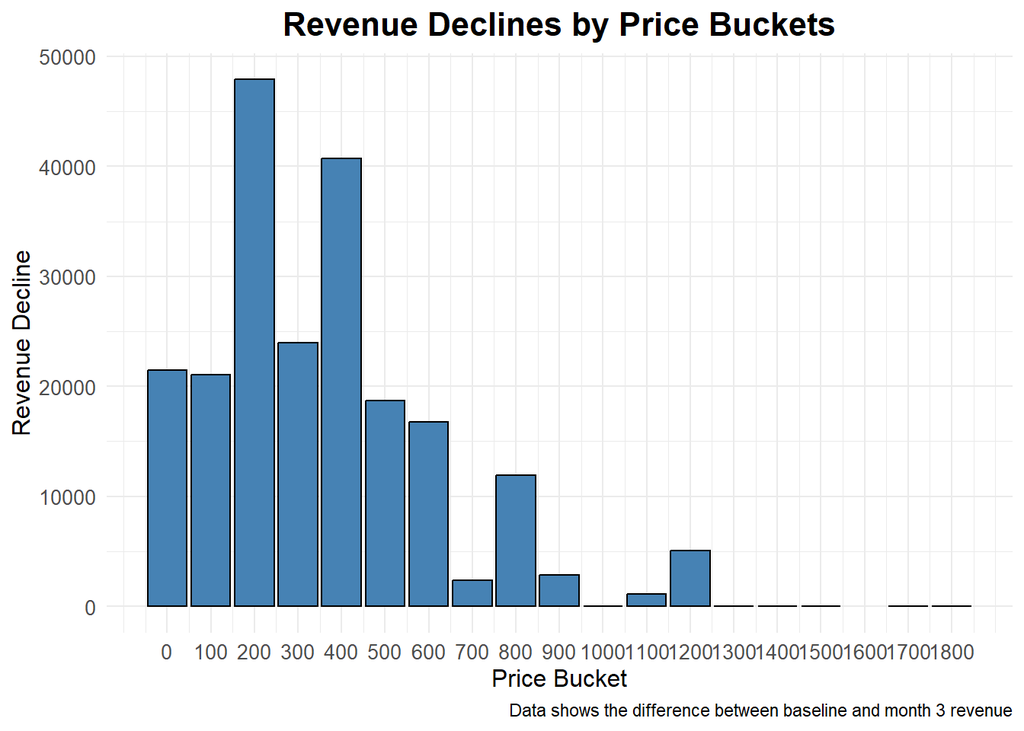

```r
# Plot revenue declines by price buckets
ggplot(price_revenue_comparison, aes(x = price_bucket, y = revenue_decline)) +
  geom_bar(stat = "identity", fill = "steelblue", color = "black") +
  labs(
    title = "Revenue Declines by Price Buckets",
    x = "Price Bucket",
    y = "Revenue Decline",
    caption = "Data shows the difference between baseline and month 3 revenue"
  ) +
  theme_minimal() +
  theme(
    plot.title = element_text(hjust = 0.5, size = 16, face = "bold"),
    axis.title = element_text(size = 12),
    axis.text = element_text(size = 10)
  ) +
  scale_x_continuous(breaks = seq(min(price_revenue_comparison$price_bucket, na.rm = TRUE),
                                  max(price_revenue_comparison$price_bucket, na.rm = TRUE),
                                  by = 100))  # Adjust tick marks as needed
```

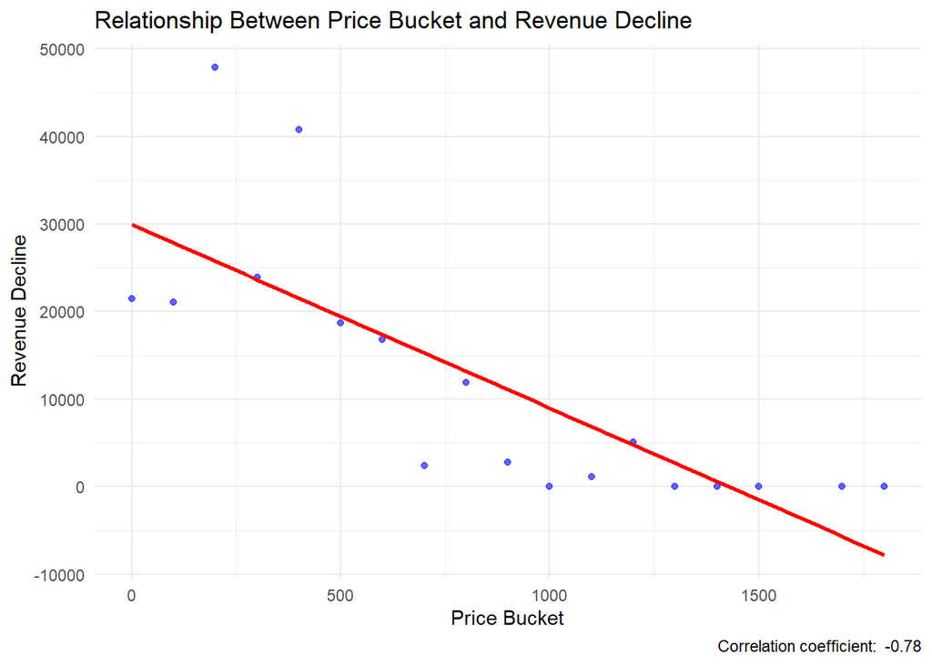

```r
# Calculate the correlation coefficient
correlation_value_price <- cor(price_revenue_comparison$price_bucket, price_revenue_comparison$revenue_decline, use = "complete.obs")

# Scatter plot with correlation coefficient
ggplot(price_revenue_comparison, aes(x = price_bucket, y = revenue_decline)) +
  geom_point(color = "blue", alpha = 0.6) + # Scatter points
  geom_smooth(method = "lm", se = FALSE, color = "red") + # Add a regression line
  labs(
    title = "Relationship Between Price Bucket and Revenue Decline",
    x = "Price Bucket",
    y = "Revenue Decline",
    caption = paste("Correlation coefficient: ", round(correlation_value_price, 2))
  ) +
  theme_minimal()
```

### User engagement

Which specific session engagement times were most impacted?

```r
# Filter only purchases from baseline and month 3
baseline_purchases <- month_baseline %>% filter(event_type == "purchase")
month3_purchases <- month_3_modified %>% filter(event_type == "purchase")

# Summarize revenue by time_day and time_hour
baseline_revenue <- baseline_purchases %>%
  group_by(time_day, time_hour) %>%
  summarise(total_revenue_baseline_time = sum(price, na.rm = TRUE), .groups = "drop")

month3_revenue <- month3_purchases %>%
  group_by(time_day, time_hour) %>%
  summarise(total_revenue_month3_time = sum(price, na.rm = TRUE), .groups = "drop")

# Merge datasets by time_day and time_hour
revenue_comparison <- merge(
  baseline_revenue,
  month3_revenue,
  by = c("time_day", "time_hour"),
  all = TRUE
)

# Replace NA with 0 (if a time_day-time_hour combination is missing in a month)
revenue_comparison[is.na(revenue_comparison)] <- 0

# Calculate revenue decline
revenue_comparison <- revenue_comparison %>%
  mutate(revenue_decline_time = total_revenue_baseline_time - total_revenue_month3_time)

# Sort by largest declines
largest_declines <- revenue_comparison %>%
  arrange(desc(revenue_decline_time))

# View the table with the biggest declines
print(head(largest_declines, 50))
```

```
##    time_day time_hour total_revenue_baseline_time total_revenue_month3_time
## 1        14        17                     8790.71                   6080.15
## 2        13         8                     4438.82                   1845.08
## 3         7         9                    11373.43                   8785.43
## 4        10        19                     9929.20                   7451.95
## 5        19        11                     4995.81                   2595.19
## 6        10        11                     5426.29                   3123.49
## 7         4        21                     9103.46                   6856.90
## 8        28        14                     6107.26                   4040.97
## 9        23        11                     4484.62                   2450.87
## 10       17        18                     5452.41                   3598.33
## 11       12         6                     6554.04                   4796.52
## 12       11        15                     3883.20                   2171.54
## 13        8         6                     7175.43                   5507.83
## 14       22        21                     4445.44                   2778.83
```

[output cut: 87 more lines]

Which specific days or times of the week were most impacted?

```r
# Summarize revenue declines by time_day
time_day_declines <- revenue_comparison %>%
  group_by(time_day) %>%
  summarise(
    total_revenue_baseline_time = sum(total_revenue_baseline_time, na.rm = TRUE),
    total_revenue_month3_time = sum(total_revenue_month3_time, na.rm = TRUE)
  ) %>%
  mutate(revenue_decline_time = total_revenue_baseline_time - total_revenue_month3_time) %>%
  arrange(desc(revenue_decline_time))

# Summarize revenue declines by time_hour
time_hour_declines <- revenue_comparison %>%
  group_by(time_hour) %>%
  summarise(
    total_revenue_baseline_time = sum(total_revenue_baseline_time, na.rm = TRUE),
    total_revenue_month3_time = sum(total_revenue_month3_time, na.rm = TRUE)
  ) %>%
  mutate(revenue_decline_time = total_revenue_baseline_time - total_revenue_month3_time) %>%
  arrange(desc(revenue_decline_time))

# View top declines for each summary
print("Top Time Day Declines:")
```

```
## [1] "Top Time Day Declines:"
```

```r
print(head(time_day_declines, 10))
```

```
## # A tibble: 10 × 4
##    time_day total_revenue_baseline…¹ total_revenue_month3…² revenue_decline_time
##       <int>                    <dbl>                  <dbl>                <dbl>
##  1       10                   63916.                 51481.               12435.
##  2        7                   64853.                 53793.               11060.
##  3       13                   63241                  53849.                9392.
##  4        4                   51013.                 41706.                9308.
##  5       17                   50940.                 41660.                9280.
##  6       12                   49006.                 39841.                9165.
##  7       15                   51039.                 41939.                9100.
##  8       25                   61550.                 52531.                9019.
##  9       11                   51854.                 42858.                8996.
## 10       28                   41300.                 32368.                8933.
## # ℹ abbreviated names: ¹total_revenue_baseline_time, ²total_revenue_month3_time
```

```r
print("Top Time Hour Declines:")
```

```
## [1] "Top Time Hour Declines:"
```

```r
print(head(time_hour_declines, 10))
```

```
## # A tibble: 10 × 4
##    time_hour total_revenue_baselin…¹ total_revenue_month3…² revenue_decline_time
##        <int>                   <dbl>                  <dbl>                <dbl>
##  1        11                  82651.                 63990.               18661.
##  2        13                  81071.                 66722.               14348.
##  3        14                  82632.                 69573.               13060.
##  4        19                  84827.                 71849.               12979.
##  5         8                  66857.                 54014.               12843.
##  6         9                  83329.                 71090.               12240.
##  7        17                  76259.                 64156.               12102.
##  8        21                  58047.                 47039.               11008.
##  9        10                  79107.                 68148.               10959.
## 10        16                  72954.                 62120.               10834.
## # ℹ abbreviated names: ¹total_revenue_baseline_time, ²total_revenue_month3_time
```

```r
# Ensure event_time is in datetime format
month_baseline$event_time <- as.POSIXct(month_baseline$event_time, format="%Y-%m-%d %H:%M:%S", tz="UTC")
month_3_modified$event_time <- as.POSIXct(month_3_modified$event_time, format="%Y-%m-%d %H:%M:%S", tz="UTC")

# Calculate the session duration for each session in baseline data
session_duration_baseline <- month_baseline %>%
  group_by(user_session) %>%
  summarise(session_start = min(event_time),
            session_end = max(event_time),
            session_duration = as.numeric(difftime(session_end, session_start, units = "secs")),
            .groups = "drop")

# Calculate the session duration for each session in month 3 data
session_duration_month3 <- month_3_modified %>%
  group_by(user_session) %>%
  summarise(session_start = min(event_time),
            session_end = max(event_time),
            session_duration = as.numeric(difftime(session_end, session_start, units = "secs")),
            .groups = "drop")

# Summarize revenue by user session in baseline data
baseline_revenue_session <- month_baseline %>%
  group_by(user_session) %>%
  summarise(total_revenue_baseline = sum(price, na.rm = TRUE), .groups = "drop")

# Summarize revenue by user session in month 3 data
month3_revenue_session <- month_3_modified %>%
  group_by(user_session) %>%
  summarise(total_revenue_month3 = sum(price, na.rm = TRUE), .groups = "drop")

# Merge session duration and revenue data for both baseline and month3
session_revenue_comparison <- session_duration_baseline %>%
  left_join(session_duration_month3, by = "user_session") %>%
  left_join(baseline_revenue_session, by = "user_session") %>%
  left_join(month3_revenue_session, by = "user_session")

# Replace NA values in numeric columns with 0 (but not in user_session)
session_revenue_comparison <- session_revenue_comparison %>%
  mutate(across(where(is.numeric), ~ replace(., is.na(.), 0)))

# Calculate revenue decline for each session
session_revenue_comparison <- session_revenue_comparison %>%
  mutate(revenue_decline = total_revenue_baseline - total_revenue_month3)

# Sort session_revenue_comparison by revenue_decline in descending order
session_revenue_comparison_sorted <- session_revenue_comparison %>%
  arrange(desc(revenue_decline))

# View the top rows of the sorted data
head(session_revenue_comparison_sorted)
```

| user_session | session_start.x | session_end.x | session_duration.x | session_start.y | session_end.y | session_duration.y | total_revenue_baseline | total_revenue_month3 | revenue_decline |
| --- | --- | --- | --- | --- | --- | --- | --- | --- | --- |
| D9N9FhMEhS | 2021-02-04 21:11:53 | 2021-02-04 22:09:55 | 3482 | 2021-02-04 21:11:53 | 2021-02-04 22:09:55 | 3482 | 29986.92 | 28020.06 | 1966.86 |
| KorWJu2Ghu | 2021-02-10 11:00:38 | 2021-02-10 11:11:55 | 677 | 2021-02-10 11:00:38 | 2021-02-10 11:11:42 | 664 | 5276.34 | 3836.99 | 1439.35 |
| 7yi1Pmq3TU | 2021-02-13 08:27:28 | 2021-02-13 08:27:28 | 0 |  |  | 0 | 1275.02 | 0.00 | 1275.02 |
| GAEZx33TBk | 2021-02-28 13:45:09 | 2021-02-28 13:46:20 | 71 | 2021-02-28 13:45:09 | 2021-02-28 13:45:18 | 9 | 3825.06 | 2550.04 | 1275.02 |
| s5n0lFoP3s | 2021-02-13 08:26:34 | 2021-02-13 08:26:34 | 0 |  |  | 0 | 1275.02 | 0.00 | 1275.02 |
| dNG0UZsqFT | 2021-02-08 05:45:33 | 2021-02-08 22:38:22 | 60769 | 2021-02-08 05:45:33 | 2021-02-08 22:38:22 | 60769 | 13853.40 | 12602.97 | 1250.43 |

Visualize the relationship between session duration (month 3) and revenue decline

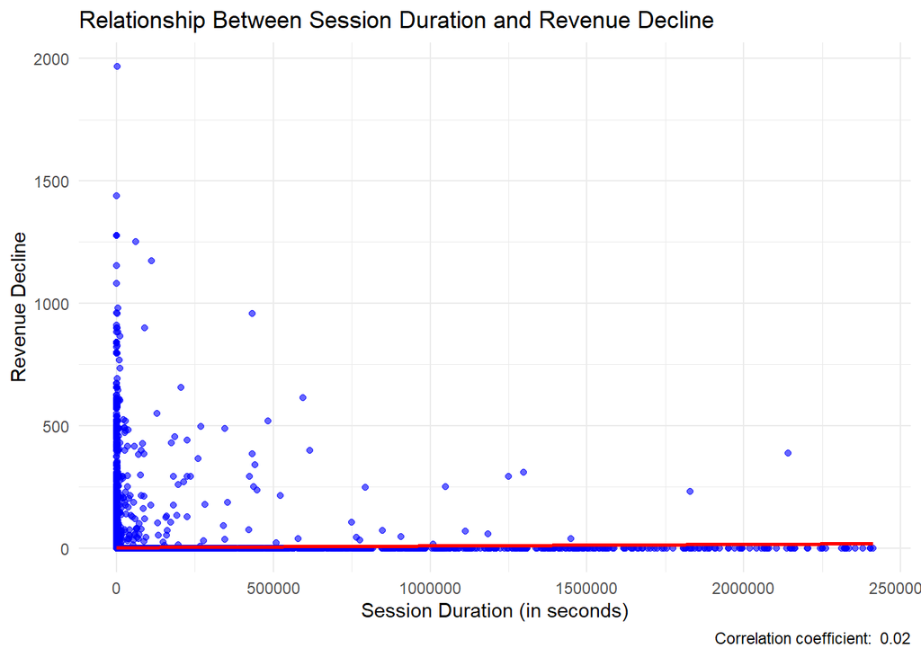

```r
# Calculate the correlation coefficient
correlation_value <- cor(session_revenue_comparison_sorted$session_duration.y, session_revenue_comparison_sorted$revenue_decline, use = "complete.obs")

# Scatter plot with correlation coefficient
ggplot(session_revenue_comparison_sorted, aes(x = session_duration.y, y = revenue_decline)) +
  geom_point(color = "blue", alpha = 0.6) + # Scatter points
  geom_smooth(method = "lm", se = FALSE, color = "red") + # Add a regression line
  labs(
    title = "Relationship Between Session Duration and Revenue Decline",
    x = "Session Duration (in seconds)",
    y = "Revenue Decline",
    caption = paste("Correlation coefficient: ", round(correlation_value, 2))
  ) +
  theme_minimal()
```

## Step 5c: User Engagement Feature Engineering

### Interaction counts

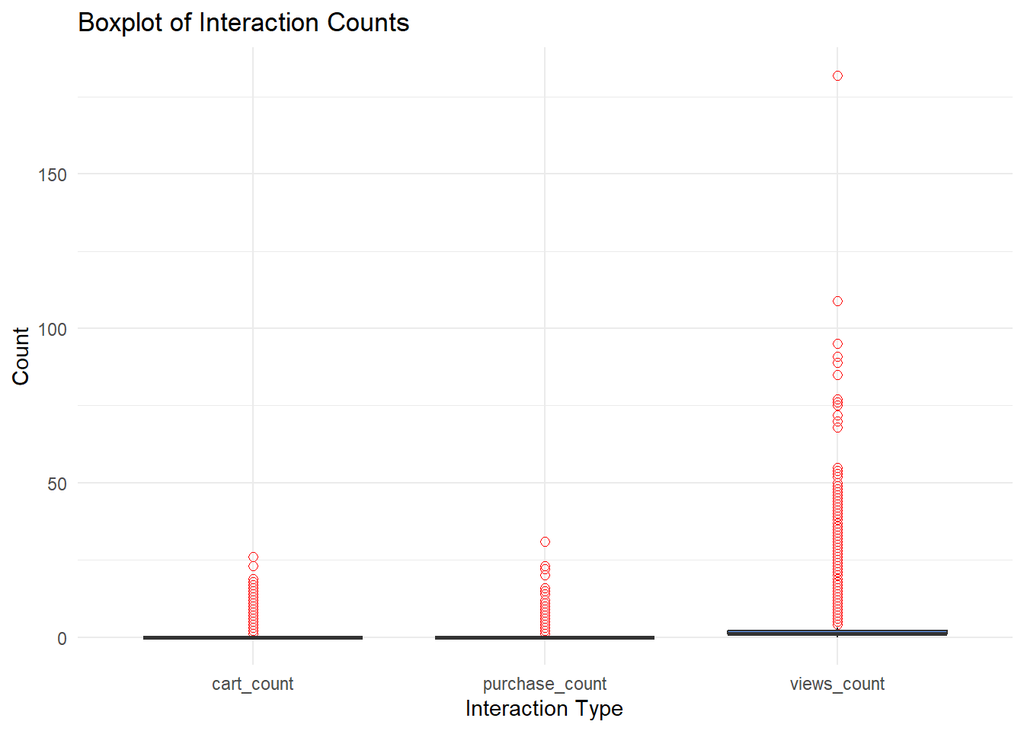

```r
# Count the number of views, carts, and purchases for each user session
interaction_counts <- month_3_modified %>%
  group_by(user_session) %>%
  summarize(
    views_count = sum(event_type == "view"),
    cart_count = sum(event_type == "cart"),
    purchase_count = sum(event_type == "purchase"),
    total_interactions = views_count + cart_count + purchase_count
  )

interaction_counts_long <- interaction_counts %>%
  pivot_longer(cols = c(views_count, cart_count, purchase_count), names_to = "interaction_type", values_to = "count")

ggplot(interaction_counts_long, aes(x = interaction_type, y = count, fill = interaction_type)) +
  geom_boxplot(outlier.colour = "red", outlier.shape = 1, outlier.size = 2) +
  labs(title = "Boxplot of Interaction Counts", x = "Interaction Type", y = "Count") +
  theme_minimal() +
  theme(legend.position = "none")
```

The boxplot illustrates the distribution of interaction counts (views, cart additions, and purchases) across sessions, highlighting significant engagement in product views compared to relatively lower cart additions and purchases.

### Session duration

```r
# Convert event_time to POSIXct
month_3_modified$event_time <- as.POSIXct(month_3_modified$event_time, format = "%Y-%m-%d %H:%M:%S", tz = "UTC")

# Calculate session duration per user session
session_duration <- month_3_modified %>%
  group_by(user_session) %>%
  summarize(session_duration = as.numeric(difftime(max(event_time), min(event_time), units = "secs")))
```

### User interaction frequency

```r
# Combine total interactions and session duration to calculate interaction frequency
interaction_frequency <- interaction_counts %>%
  left_join(session_duration, by = "user_session") %>%
  mutate(interaction_frequency = total_interactions / (session_duration / 60 + 1))  # Avoid division by zero
```

### Category diversity

```r
# Count the number of unique categories per session
category_diversity <- month_3_modified %>%
  group_by(user_session) %>%
  summarize(category_diversity = n_distinct(category_1))
```

### Merge features

```r
# Merge all features into the main dataset
features <- interaction_counts %>%
  left_join(session_duration, by = "user_session") %>%
  left_join(interaction_frequency %>% select(user_session, interaction_frequency), by = "user_session") %>%
  left_join(category_diversity, by = "user_session")

# Add features to the main dataset
month_3_modified <- month_3_modified %>%
  left_join(features, by = "user_session")
```

```r
# Create a binary field indicating if a session resulted in a conversion from cart to purchase
cart_to_purchase <- month_3_modified %>%
  group_by(user_session) %>%
  summarize(
    cart_events = sum(event_type == "cart"),  # Count cart events
    purchase_events = sum(event_type == "purchase"),  # Count purchase events
    cart_to_purchase = ifelse(cart_events > 0 & purchase_events > 0, 1, 0)  # 1 if conversion occurred, 0 otherwise
  )

# Merge cart-to-purchase conversion field into the main dataset
month_3_modified <- month_3_modified %>%
  left_join(cart_to_purchase, by = "user_session")
```

# **PREDICTIVE MODELING**

In this section, our goal is to understand the features and predict the decision likelihood for cart-to-purchase conversion

We will use classification tree, random forest, and logistic regression and compare the performance of each model.

# **Step 6: Plot and compare all three models**

## Step 6a: Prepare dataset

```r
# Check for missing values in the dataset
colSums(is.na(month_3_modified))
```

```
##            event_time            event_type            product_id
##                     0                     0                     0
##           category_id         category_code                 brand
##                     0                     0                     0
##                 price               user_id          user_session
##                     0                     0                     0
##            time_month              time_day             time_hour
##                     0                     0                     0
##            category_1            category_2            category_3
##                 40428                 40428                 73067
##             price_log            price_sqrt           views_count
##                     0                     0                     0
##            cart_count        purchase_count    total_interactions
##                     0                     0                     0
##      session_duration interaction_frequency    category_diversity
##                     0                     0                     0
##           cart_events       purchase_events      cart_to_purchase
##                     0                     0                     0
```

```r
# Remove rows with any missing values
month_3_modified <- month_3_modified %>%
  drop_na()
```

## Step 6b: Training and test sets

```r
# Ensure cart_to_purchase is a factor
month_3_modified$cart_to_purchase <- as.factor(month_3_modified$cart_to_purchase)

# Create training and validation sets
set.seed(123)  # For reproducibility
train_index <- createDataPartition(month_3_modified$cart_to_purchase, p = 0.8, list = FALSE)
train_data <- month_3_modified[train_index, ]
test_data <- month_3_modified[-train_index, ]
```

## Step 6c: Compare random forest, classification tree, and logistic models

```r
#Convert Y variable to factor type
train_data$cart_to_purchase <- as.factor(train_data$cart_to_purchase)
test_data$cart_to_purchase <- as.factor(test_data$cart_to_purchase)

# Random Forest Model
rf_model <- randomForest(
  formula = cart_to_purchase ~ views_count + cart_count + session_duration + price + category_diversity + category_1,
  data = train_data,
  ntree = 400,
  replace = TRUE,
  importance = TRUE
)

# Logistic Regression model
logistic_model <- glm(cart_to_purchase ~ views_count + cart_count + session_duration + price + category_diversity + category_1,
                      family = "binomial", data = train_data)

# Classification Tree model
tree_model <- rpart(cart_to_purchase ~ views_count + cart_count + session_duration + price + category_diversity + category_1,
                    method = "class", data = train_data)
printcp(tree_model)
```

```
##
## Classification tree:
## rpart(formula = cart_to_purchase ~ views_count + cart_count +
##     session_duration + price + category_diversity + category_1,
##     data = train_data, method = "class")
##
## Variables actually used in tree construction:
## [1] cart_count       session_duration views_count
##
## Root node error: 13659/74130 = 0.18426
##
## n= 74130
##
##         CP nsplit rel error  xerror      xstd
## 1 0.147888      0   1.00000 1.00000 0.0077280
## 2 0.021597      2   0.70422 0.70979 0.0067208
## 3 0.017864      4   0.66103 0.66279 0.0065267
## 4 0.010000      5   0.64317 0.64829 0.0064648
```

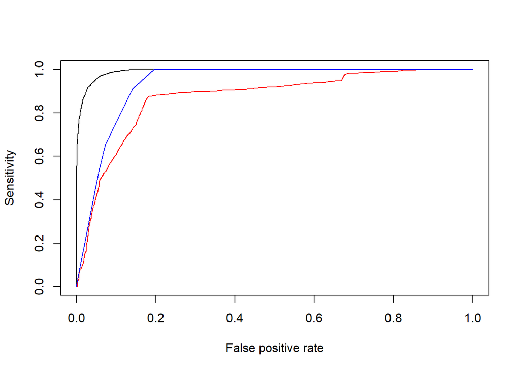

```r
# Random Forest model predictions
pred.prob.rf <- predict(rf_model, test_data, type = "prob")[, 2]

# Logistic model predictions
pred.prob.logistic <- predict(logistic_model, test_data, type = "response")

# Pruned classification tree predictions
pred.prob.tree <- predict(tree_model, test_data, type = "prob")[, 2]

# ROC for Random Forest, Logistic, and Tree models
roc.rf <- performance(prediction(pred.prob.rf, test_data$cart_to_purchase), "sens", "fpr")
roc.logistic <- performance(prediction(pred.prob.logistic, test_data$cart_to_purchase), "sens", "fpr")
roc.tree <- performance(prediction(pred.prob.tree, test_data$cart_to_purchase), "sens", "fpr")

# Plot all three ROC curves
plot(roc.rf)
plot(roc.logistic, col = "red", add = TRUE)
plot(roc.tree, col = "blue", add = TRUE)
```

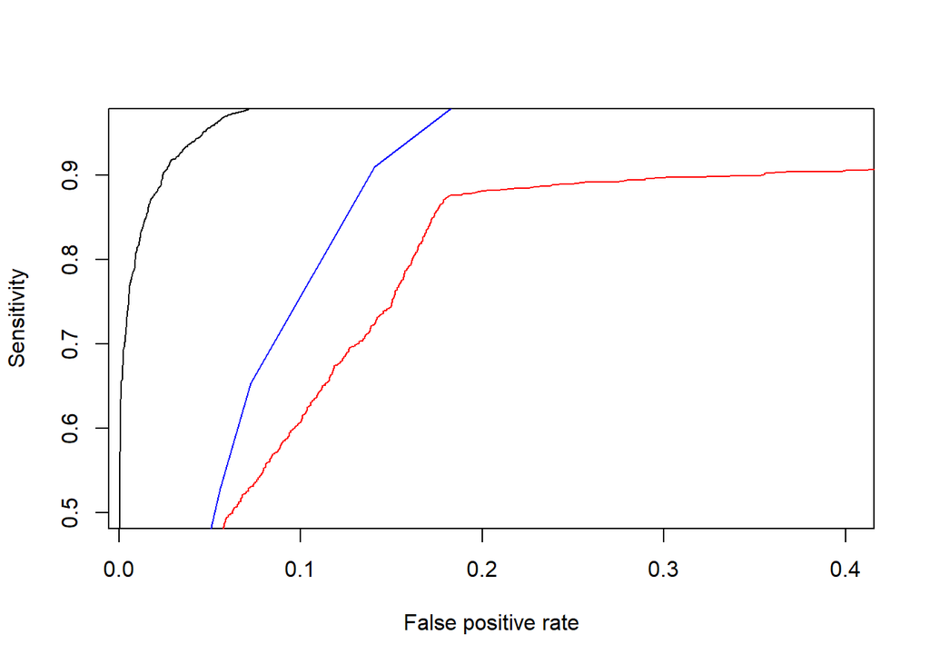

```r
# Sensitivity chart for all models
plot(roc.rf, xlim = c(0.01, 0.4), ylim = c(0.5, 0.96))
plot(roc.logistic, col = "red", add = TRUE)
plot(roc.tree, col = "blue", add = TRUE)
```

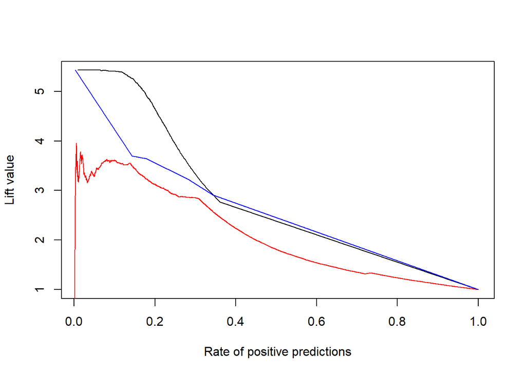

```r
# LIFT curve for all models
lift.rf <- performance(prediction(pred.prob.rf, test_data$cart_to_purchase), "lift", "rpp")
lift.logistic <- performance(prediction(pred.prob.logistic, test_data$cart_to_purchase), "lift", "rpp")
lift.tree <- performance(prediction(pred.prob.tree, test_data$cart_to_purchase), "lift", "rpp")

# Plot all three LIFT curves
plot(lift.rf)
plot(lift.logistic, col = "red", add = TRUE)
plot(lift.tree, col = "blue", add = TRUE)
```

```r
# AUC for all models
auc.rf <- performance(prediction(pred.prob.rf, test_data$cart_to_purchase), "auc")@y.values
auc.logistic <- performance(prediction(pred.prob.logistic, test_data$cart_to_purchase), "auc")@y.values
auc.tree <- performance(prediction(pred.prob.tree, test_data$cart_to_purchase), "auc")@y.values

auc.rf
```

```
## [[1]]
## [1] 0.9921761
```

```r
auc.logistic
```

```
## [[1]]
## [1] 0.8698229
```

```r
auc.tree
```

```
## [[1]]
## [1] 0.9351152
```

Based on the higher area under the curve for random forest, we will select this as our conversion predictive model.

## Step 6d: Analyze the Random Forest Model

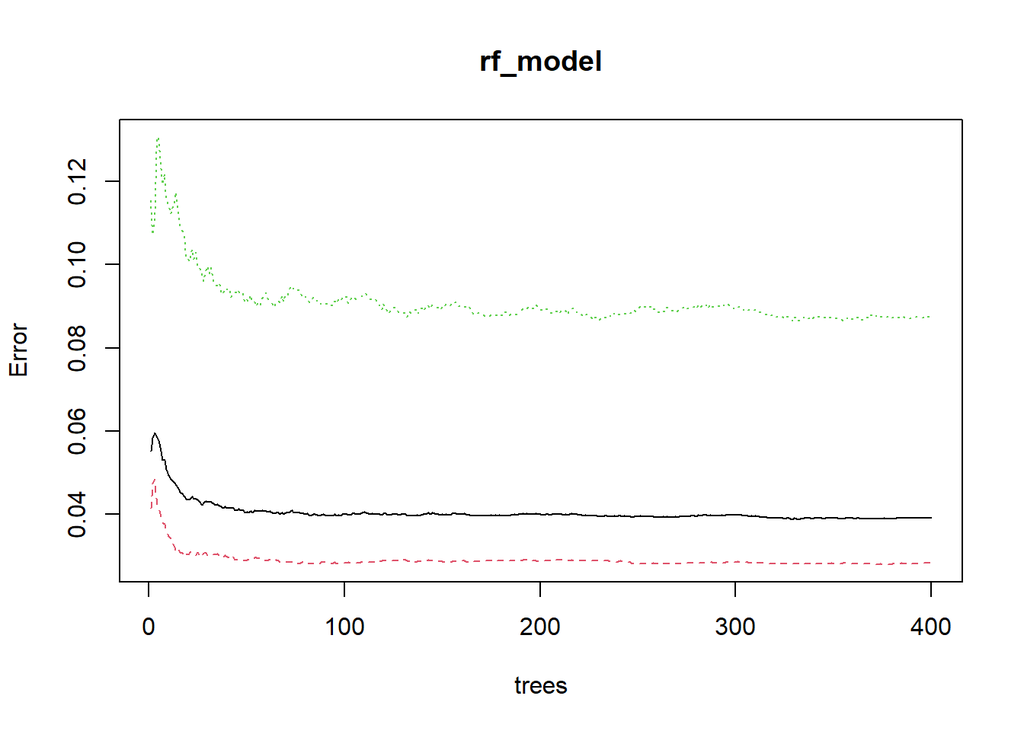

```r
# Plot the Random Forest model
plot(rf_model)
```

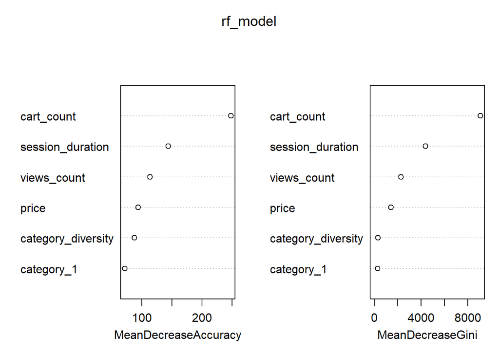

```r
# Plot the variable importance
varImpPlot(rf_model)
```

```r
# Predict the probabilities of the second class (1 = cart-to-purchase)
pred.prob.rf <- predict(rf_model, test_data, type = "prob")[, 2]

# Create confusion matrix
conf_matrix <- table(test_data$cart_to_purchase, pred.prob.rf > 0.5)
conf_matrix
```

```
##
##     FALSE  TRUE
##   0 14703   414
##   1   306  3108
```

```r
# Extract values from the confusion matrix
true_negatives <- conf_matrix[1, 1]  # Actual 0, Predicted FALSE
false_positives <- conf_matrix[1, 2]  # Actual 0, Predicted TRUE
false_negatives <- conf_matrix[2, 1]  # Actual 1, Predicted FALSE
true_positives <- conf_matrix[2, 2]  # Actual 1, Predicted TRUE

true_negatives
```

```
## [1] 14703
```

```r
false_positives
```

```
## [1] 414
```

```r
false_negatives
```

```
## [1] 306
```

```r
true_positives
```

```
## [1] 3108
```

```r
# Misclassification rate
misclassification_rate <- (false_positives + false_negatives) / sum(conf_matrix)
misclassification_rate
```

```
## [1] 0.03885381
```

```r
# Class 1 error rate (False Negative Rate)
class_1_error_rate <- false_negatives / (true_positives + false_negatives)
class_1_error_rate
```

```
## [1] 0.08963093
```

```r
# Class 0 error rate (False Positive Rate)
class_0_error_rate <- false_positives / (false_positives + true_negatives)
class_0_error_rate
```

```
## [1] 0.02738639
```

```r
# Precision: True Positives / (True Positives + False Positives)
precision <- true_positives / (true_positives + false_positives)
precision
```

```
## [1] 0.8824532
```

```r
# Negative Predictive Value: True Negatives / (True Negatives + False Negatives)
npv <- true_negatives / (true_negatives + false_negatives)
npv
```

```
## [1] 0.9796122
```

```r
# ROC and AUC
pred.rf <- prediction(pred.prob.rf, test_data$cart_to_purchase)
performance(pred.rf, measure = "auc")@y.values
```

```
## [[1]]
## [1] 0.9921761
```

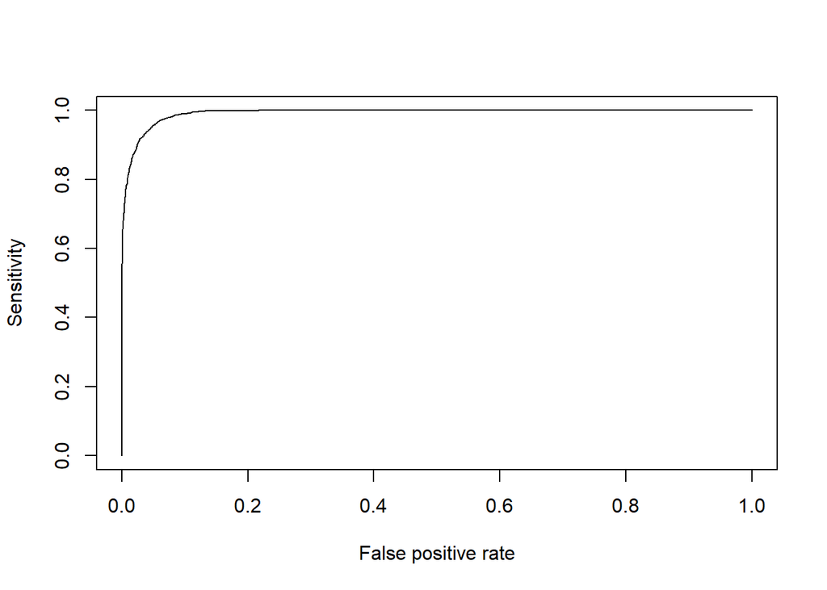

```r
roc.rf <- performance(pred.rf, "sens", "fpr")
plot(roc.rf)
```

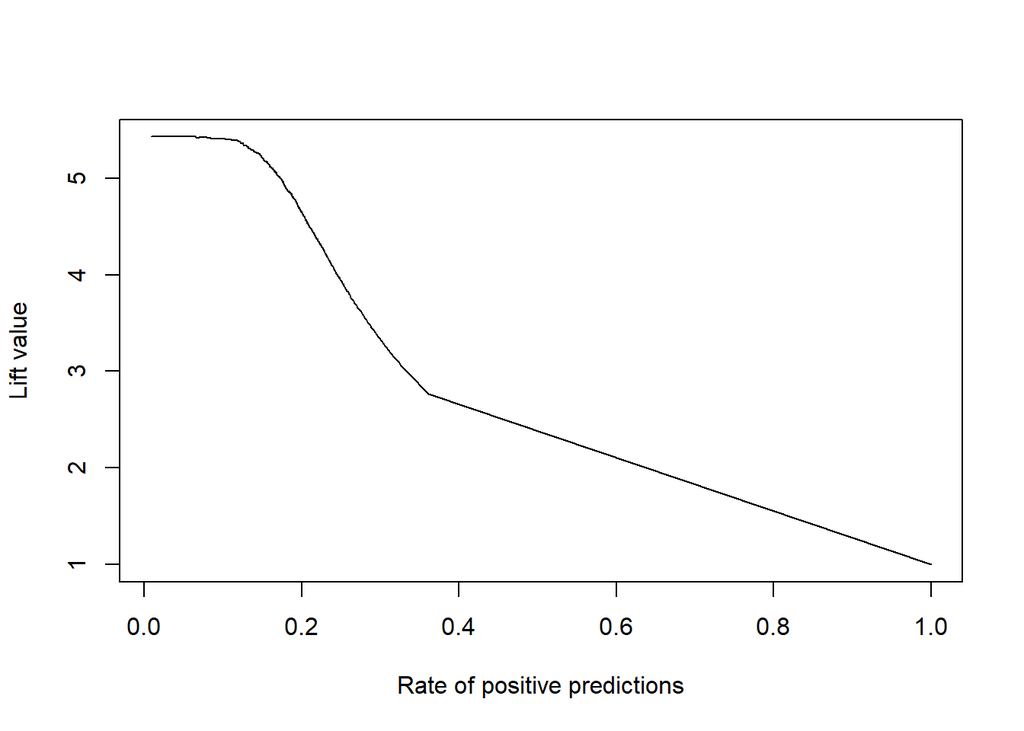

```r
# LIFT curve
lift.rf <- performance(pred.rf, "lift", "rpp")
plot(lift.rf)
```

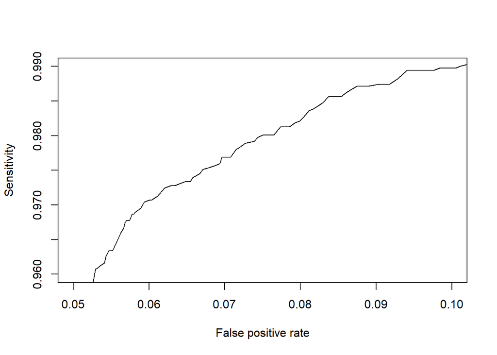

```r
# Sensitivity chart
plot(roc.rf, xlim = c(0.05, 0.10), ylim = c(0.96, 0.99))
```

# **Step 7: Analysis to recover lost revenue - overall increased conversion model**

Here, we provide the user with a tool to simulate a third month in which the higher likelihood sessions are promoted, sufficient to ensure that the total value of price column for purchases increases from $1,162,885 in March to $1,376,806 in April.

## Step 7a: Apply prediction likelihood to dataset

```r
# Ensure cart_to_purchase is a factor for prediction
month_3_modified$cart_to_purchase <- as.factor(month_3_modified$cart_to_purchase)

# Predict the probabilities for the entire month_3_modified dataset
pred.prob.rf <- predict(rf_model, month_3_modified, type = "prob")[, 2]

# Add the predicted probabilities to the dataset as conversion likelihood
month_3_modified$conversion_likelihood <- pred.prob.rf

# Check the first few rows to ensure the likelihood is correctly added
head(month_3_modified)
```

|  | event_time | event_type | product_id | category_id | category_code | brand | price | user_id | user_session | time_month | time_day | time_hour | category_1 | category_2 | category_3 | price_log | price_sqrt | views_count | cart_count | purchase_count | total_interactions | session_duration | interaction_frequency | category_diversity | cart_events | purchase_events | cart_to_purchase | conversion_likelihood |
| --- | --- | --- | --- | --- | --- | --- | --- | --- | --- | --- | --- | --- | --- | --- | --- | --- | --- | --- | --- | --- | --- | --- | --- | --- | --- | --- | --- | --- |
| 1 | 2021-02-01 00:01:21 | view | 4100254 | 2.14442e+18 | computers.components.videocards | asus | 187.29 | 1515915625599170048 | mJndx3tNRh | 3 | 1 | 0 | computers | components | videocards | 5.232658 | 13.685394 | 2 | 0 | 0 | 2 | 148 | 0.576923077 | 1 | 0 | 0 | 0 | 0 |
| 2 | 2021-02-01 00:02:01 | view | 4079414 | 2.14442e+18 | electronics.video.tv | starwind | 87.46 | 1515915625599239936 | GprKXGbhaV | 3 | 1 | 0 | electronics | video | tv | 4.471182 | 9.352005 | 1 | 0 | 0 | 1 | 0 | 1.000000000 | 1 | 0 | 0 | 0 | 0 |
| 3 | 2021-02-01 00:03:06 | view | 3828462 | 2.14442e+18 | electronics.audio.headphone | steelseries | 201.33 | 1515915625595379968 | VUViO6czhP | 3 | 1 | 0 | electronics | audio | headphone | 5.304945 | 14.189080 | 3 | 0 | 0 | 3 | 81503 | 0.002206883 | 1 | 0 | 0 | 0 | 0 |
| 4 | 2021-02-01 00:03:49 | view | 893196 | 2.14442e+18 | computers.components.videocards | sapphire | 214.10 | 1515915625599170048 | mJndx3tNRh | 3 | 1 | 0 | computers | components | videocards | 5.366443 | 14.632156 | 2 | 0 | 0 | 2 | 148 | 0.576923077 | 1 | 0 | 0 | 0 | 0 |
| 5 | 2021-02-01 00:03:54 | view | 498174 | 2.14442e+18 | computers.components.tv_tuner | bbk | 23.13 | 1515915625599239936 | amXrRlAZWn | 3 | 1 | 0 | computers | components | tv_tuner | 3.141130 | 4.809366 | 1 | 0 | 0 | 1 | 0 | 1.000000000 | 1 | 0 | 0 | 0 | 0 |
| 6 | 2021-02-01 00:04:24 | view | 3699987 | 2.14442e+18 | electronics.audio.acoustic | jbl | 43.13 | 1515915625599150080 | neoL2HLkUs | 3 | 1 | 0 | electronics | audio | acoustic | 3.764219 | 6.567343 | 2 | 0 | 0 | 2 | 114 | 0.689655172 | 1 | 0 | 0 | 0 | 0 |

## Step 7b: Simulate revenue recovery

```r
#Step 1: Define the top x% of purchase likelihood sessions to replicate and bottom x% to remove
top_percentage <- 0.21  # Example: Promote top 20% of sessions
bottom_percentage <- 0.2  # Example: Remove bottom 20% of sessions
```

```r
#Step 2: Filter purchase events
purchase_data <- month_3_modified %>% filter(event_type == "purchase")
```

```r
#Step 3: Sort purchase data by conversion likelihood (highest to lowest)
purchase_data_sorted <- purchase_data %>%
  arrange(desc(conversion_likelihood))
head(purchase_data_sorted)
```

|  | event_time | event_type | product_id | category_id | category_code | brand | price | user_id | user_session | time_month | time_day | time_hour | category_1 | category_2 | category_3 | price_log | price_sqrt | views_count | cart_count | purchase_count | total_interactions | session_duration | interaction_frequency | category_diversity | cart_events | purchase_events | cart_to_purchase | conversion_likelihood |
| --- | --- | --- | --- | --- | --- | --- | --- | --- | --- | --- | --- | --- | --- | --- | --- | --- | --- | --- | --- | --- | --- | --- | --- | --- | --- | --- | --- | --- |
| 1 | 2021-02-01 20:27:06 | purchase | 3507403 | 2.14442e+18 | computers.components.motherboard | gigabyte | 63.02 | 1515915625591650048 | F6ohHpTTBU | 3 | 1 | 20 | computers | components | motherboard | 4.143452 | 7.938514 | 91 | 18 | 23 | 132 | 82763 | 0.09562561 | 3 | 18 | 23 | 1 | 1 |
| 2 | 2021-02-01 20:27:06 | purchase | 3581574 | 2.14442e+18 | computers.components.motherboard | asus | 88.52 | 1515915625591650048 | F6ohHpTTBU | 3 | 1 | 20 | computers | components | motherboard | 4.483229 | 9.408507 | 91 | 18 | 23 | 132 | 82763 | 0.09562561 | 3 | 18 | 23 | 1 | 1 |
| 3 | 2021-02-01 20:27:06 | purchase | 3660474 | 2.14442e+18 | computers.components.motherboard | asrock | 91.19 | 1515915625591650048 | F6ohHpTTBU | 3 | 1 | 20 | computers | components | motherboard | 4.512945 | 9.549346 | 91 | 18 | 23 | 132 | 82763 | 0.09562561 | 3 | 18 | 23 | 1 | 1 |
| 4 | 2021-02-01 20:47:44 | purchase | 3507403 | 2.14442e+18 | computers.components.motherboard | gigabyte | 63.02 | 1515915625591650048 | F6ohHpTTBU | 3 | 1 | 20 | computers | components | motherboard | 4.143452 | 7.938514 | 91 | 18 | 23 | 132 | 82763 | 0.09562561 | 3 | 18 | 23 | 1 | 1 |
| 5 | 2021-02-01 20:49:14 | purchase | 3507403 | 2.14442e+18 | computers.components.motherboard | gigabyte | 63.02 | 1515915625591650048 | F6ohHpTTBU | 3 | 1 | 20 | computers | components | motherboard | 4.143452 | 7.938514 | 91 | 18 | 23 | 132 | 82763 | 0.09562561 | 3 | 18 | 23 | 1 | 1 |
| 6 | 2021-02-01 21:12:21 | purchase | 4155048 | 2.14442e+18 | computers.components.videocards | msi | 247.40 | 1515915625591650048 | F6ohHpTTBU | 3 | 1 | 21 | computers | components | videocards | 5.511006 | 15.728954 | 91 | 18 | 23 | 132 | 82763 | 0.09562561 | 3 | 18 | 23 | 1 | 1 |

```r
#Step 4: Calculate how many rows to keep for top x% and bottom x%
top_rows_count <- floor(nrow(purchase_data_sorted) * top_percentage)
bottom_rows_count <- floor(nrow(purchase_data_sorted) * bottom_percentage)
```

```r
#Step 5: Select top x% and bottom x% sessions
top_sessions <- purchase_data_sorted[1:top_rows_count, ]
bottom_sessions <- purchase_data_sorted[(nrow(purchase_data_sorted) - bottom_rows_count + 1):nrow(purchase_data_sorted), ]
```

```r
#Step 6: Remove the bottom x% sessions from purchase data
purchase_data_modified <- purchase_data_sorted[!purchase_data_sorted$user_session %in% bottom_sessions$user_session, ]
```

```r
#Step 7: Replicate the top x% sessions
purchase_data_modified <- rbind(purchase_data_modified, top_sessions)
```

```r
#Step 8: Combine the modified purchase data with the non-purchase data
non_purchase_data <- month_3_modified %>% filter(event_type != "purchase")
month_3_modified_replicated <- rbind(purchase_data_modified, non_purchase_data)
```

```r
#Step 9: Calculate the total purchase value for the replicated dataset before and after modification
total_purchase_value_original <- sum(month_3_modified$price[month_3_modified$event_type == "purchase"])
total_purchase_value_modified <- sum(month_3_modified_replicated$price[month_3_modified_replicated$event_type == "purchase"])
```

```r
 #Step 10: Ensure the purchase value for Month 4 matches the target value
target_total_value_month4 <- 1376806  # Target purchase value for Month 4

if (total_purchase_value_modified < target_total_value_month4) {
   #Calculate how much value we still need to add
  value_needed <- target_total_value_month4 - total_purchase_value_modified

  #If necessary, replicate the top sessions further to reach the target value
  additional_sessions_needed <- ceiling(value_needed / mean(top_sessions$price))
  additional_sessions <- top_sessions[sample(nrow(top_sessions), additional_sessions_needed, replace = TRUE), ]

  #Add the additional sessions to the modified data
  month_3_modified_replicated <- rbind(month_3_modified_replicated, additional_sessions)

 # Recalculate the new total purchase value
  total_purchase_value_modified <- sum(month_3_modified_replicated$price[month_3_modified_replicated$event_type == "purchase"])

  cat("Adjusted purchase value for Month 4 (after adding more top sessions):", total_purchase_value_modified, "\n")
}
```

```
## Adjusted purchase value for Month 4 (after adding more top sessions): 1388493
```

```r
#Step 11: Save the modified dataset
write.csv(month_3_modified_replicated, "month_4_simulated_with_adjustment.csv", row.names = FALSE)
cat("Month 4 simulated dataset saved as 'month_4_simulated_with_adjustment.csv'.\n")
```

```
## Month 4 simulated dataset saved as 'month_4_simulated_with_adjustment.csv'.
```